# Open Meteo Weather Exploration

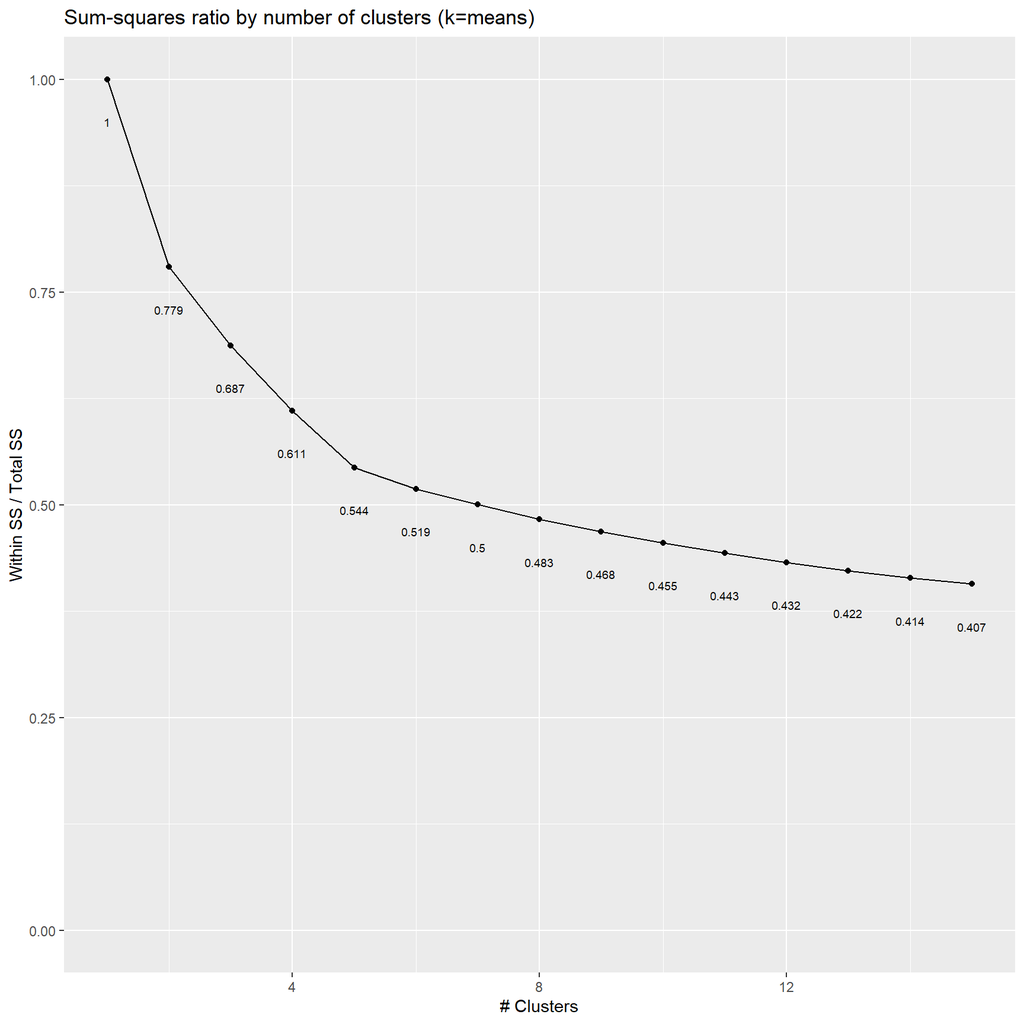

```r
dfSS %>%
    ggplot(aes(x=nCluster, y=pmin(1, pct))) +
    geom_point() +
    geom_line() +
    lims(y=c(0, 1)) +
    labs(x="# Clusters",
         y="Within SS / Total SS",
         title="Sum-squares ratio by number of clusters (k=means)"
         ) +
    geom_text(aes(y=pct-0.05, label=round(pct, 3)), size=2.5)
```

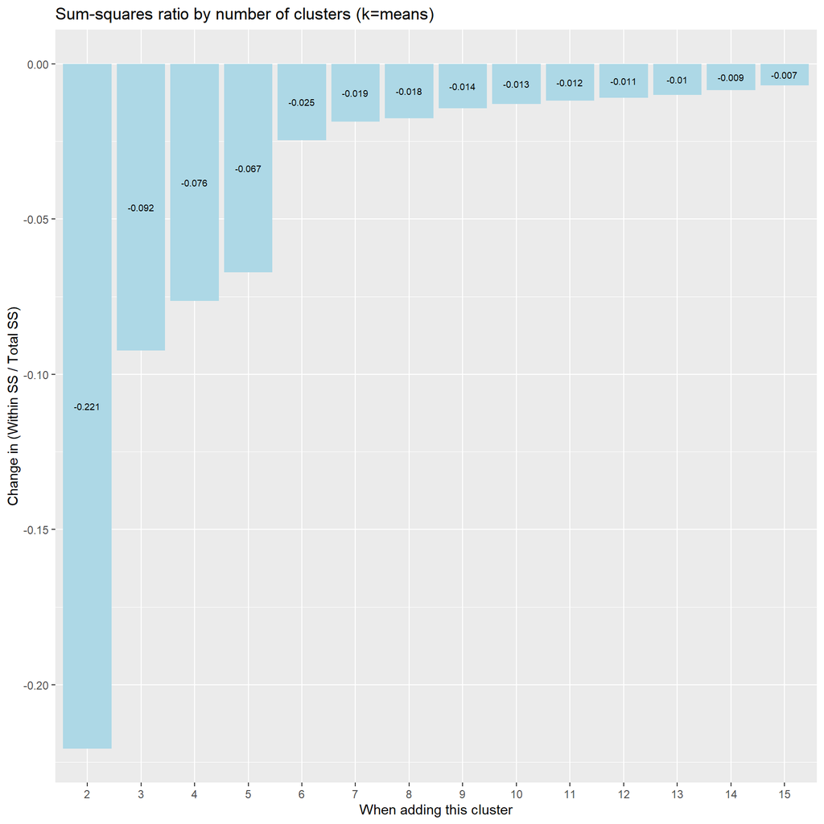

```r
dfSS %>%
    filter(!is.na(dpct)) %>%
    ggplot(aes(x=factor(nCluster), y=dpct)) +
    geom_col(fill="lightblue") +
    labs(x="When adding this cluster",
         y="Change in (Within SS / Total SS)",
         title="Sum-squares ratio by number of clusters (k=means)"
         ) +
    geom_text(aes(y=dpct/2, label=round(dpct, 3)), size=2.5)
```

- The first cluster added (k=2) causes ~20% drop in SS-within
- The next three clusters added (k=3, 4, 5) each cause 5%-10% drop in SS-within
- Clusters after k=5 have consistent, modest drops in SS-within

This is suggestive that exploring evolution of data splits at k = 1, 2, 3, 4, 5 may be informative

The assignKMeans() functionality is tested:

```r
# Example of returning distance data
glimpse(assignKMeans(km=nycKMList[[10]], df=nycTempTrain, returnAllDistanceData=TRUE))
```

```
## Rows: 88,452
## Columns: 11
## $ V1  <dbl> 291.1435, 286.5308, 245.5082, 250.7208, 246.9744, 243.3741, 246.27…
## $ V2  <dbl> 323.4492, 326.5322, 289.4243, 286.3461, 279.3103, 278.8232, 253.60…
## $ V3  <dbl> 188.7837, 197.5598, 226.4654, 221.9406, 211.6541, 211.3554, 210.01…
## $ V4  <dbl> 275.3905, 275.5157, 234.9525, 237.1705, 231.7343, 229.0003, 199.43…
## $ V5  <dbl> 261.0590, 263.9333, 222.6504, 219.1689, 210.4299, 209.5118, 217.62…
## $ V6  <dbl> 358.7661, 354.8273, 322.1453, 325.5176, 322.7495, 320.4959, 294.47…
## $ V7  <dbl> 283.9546, 288.0497, 305.6469, 302.8877, 296.2321, 295.9944, 274.38…
## $ V8  <dbl> 307.6029, 299.4418, 256.8930, 263.4953, 261.7918, 257.9137, 226.34…
## $ V9  <dbl> 199.8582, 202.7813, 145.6591, 144.7558, 133.0292, 130.2691, 139.80…
## $ V10 <dbl> 248.5199, 239.4626, 186.2984, 196.5638, 194.4515, 188.2631, 192.11…
## $ cl  <int> 3, 3, 9, 9, 9, 9, 9, 4, 4, 4, 4, 4, 4, 4, 9, 9, 9, 9, 9, 3, 3, 9, …
```

```r
# Confirmation that cluster assignments match (could occasionally have a tied distance and possible mismatch)
table(assignKMeans(km=nycKMList[[10]], df=nycTempTrain), nycKMList[[10]]$cluster)
```

```
##
##          1     2     3     4     5     6     7     8     9    10
##   1   9397     0     0     0     0     0     0     0     0     0
##   2      0  9719     0     0     0     0     0     0     0     0
##   3      0     0  7010     0     0     0     0     0     0     0
##   4      0     0     0  8805     0     0     0     0     0     0
##   5      0     0     0     0  8498     0     0     0     0     0
##   6      0     0     0     0     0 11024     0     0     0     0
##   7      0     0     0     0     0     0  3734     0     0     0
##   8      0     0     0     0     0     0     0  8534     0     0
##   9      0     0     0     0     0     0     0     0 10298     0
##   10     0     0     0     0     0     0     0     0     0 11433
```

The function successfully assigns points to the nearest centroid, consistent with the output of kmeans()

The output of 4 k-means clusters is explored:

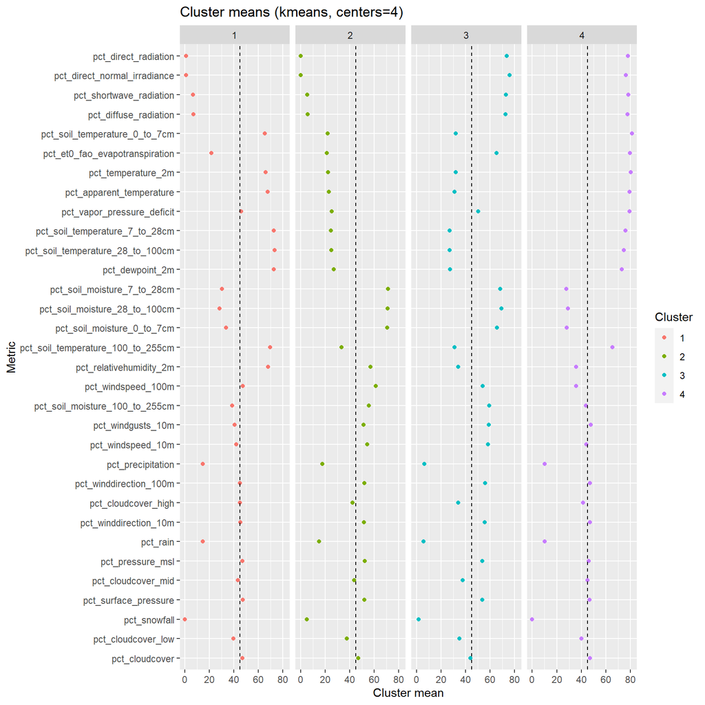

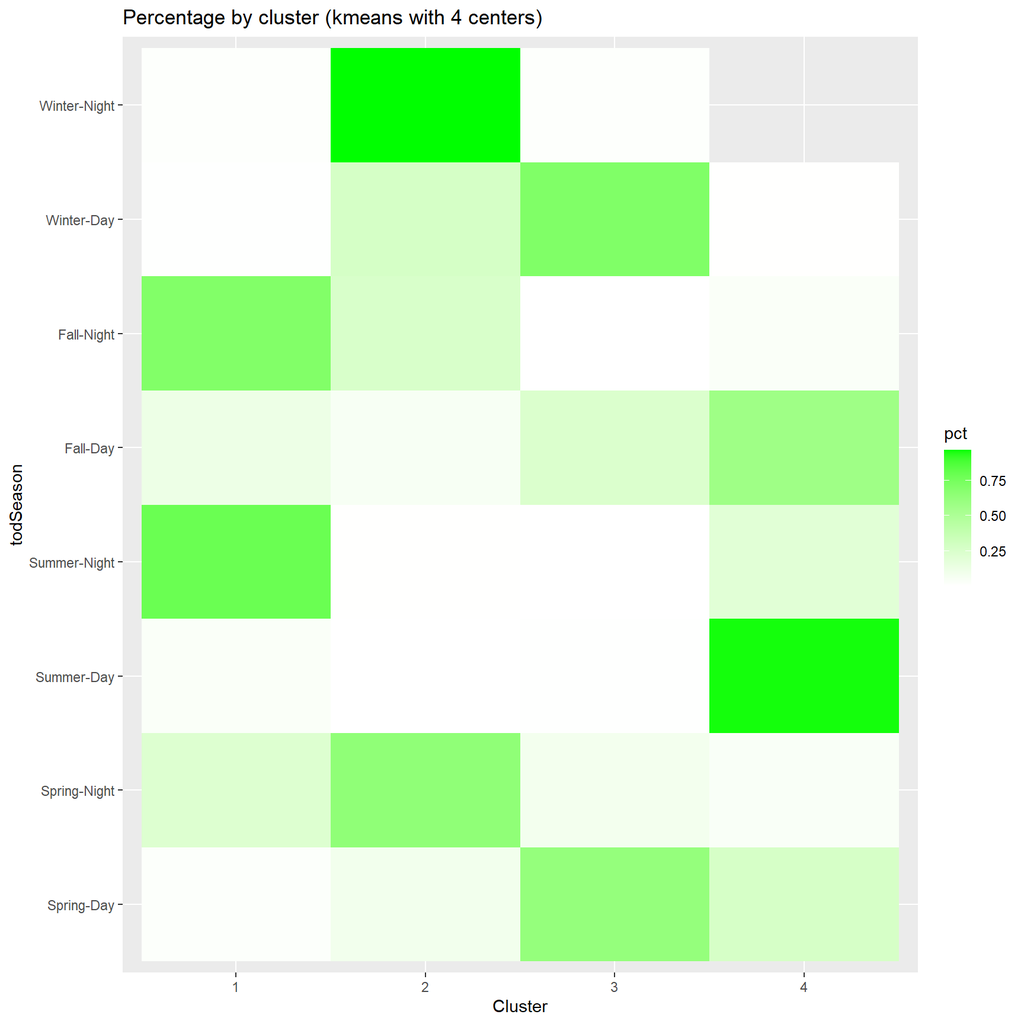

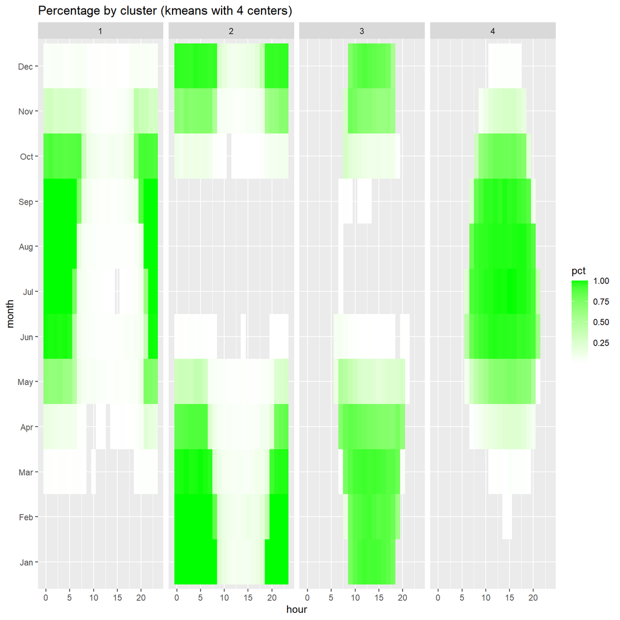

```r
# Function run on the 4-cluster k-means object
runKMeans(df=nycTempTrain,
          km=nycKMList[[4]],
          plotMeans=TRUE,
          plotPct=list(c("todSeason"), c("hour", "month")),
          nrowPct=1,
          nrowMeans=1
          )
```

Clusters include the four quadrants of day/night and warm/cold season

The output of 5 k-means clusters is explored:

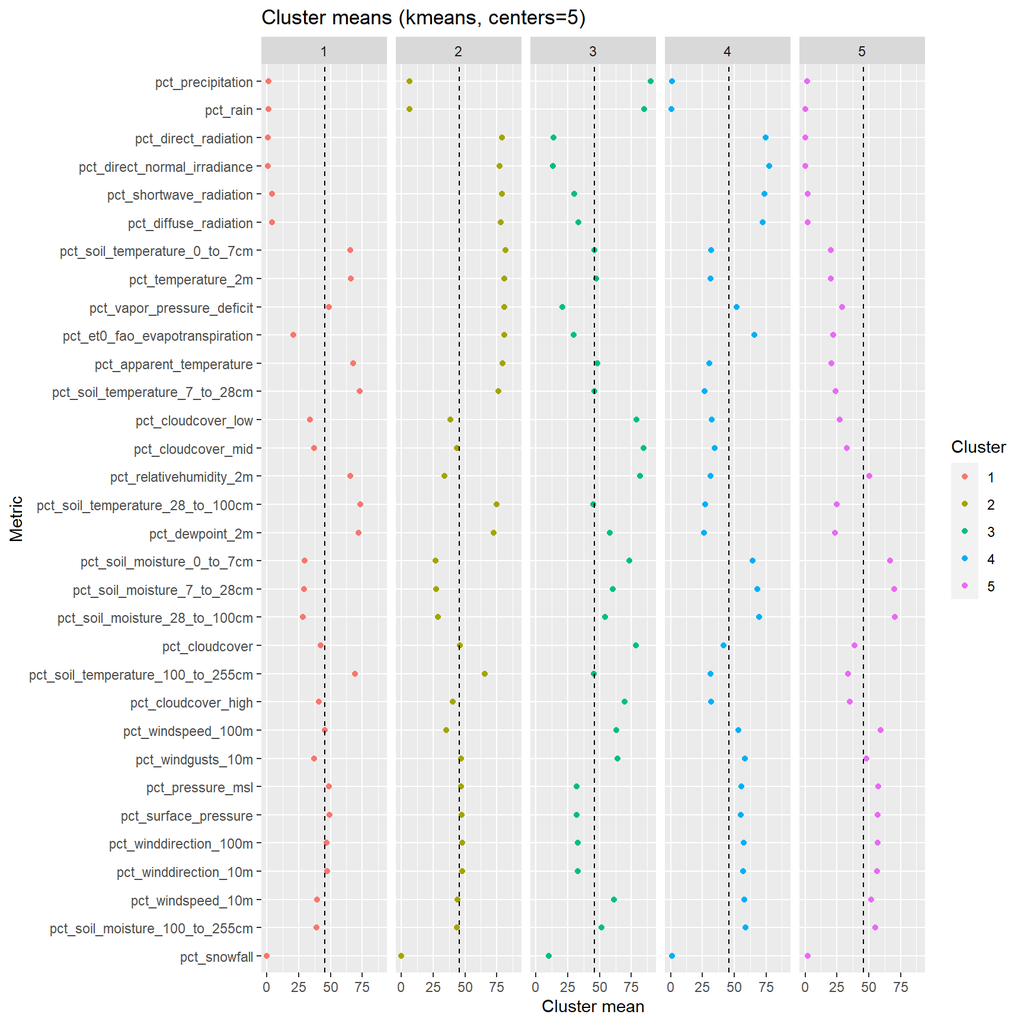

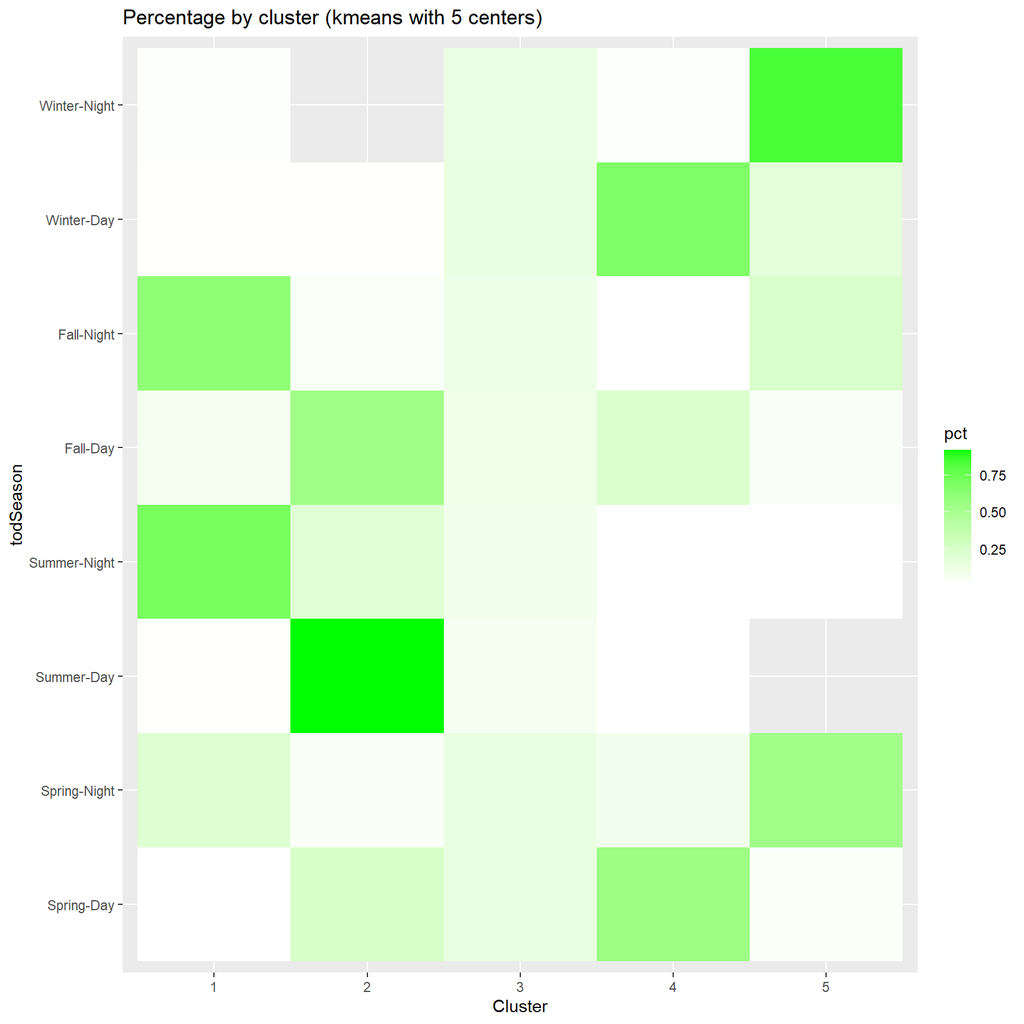

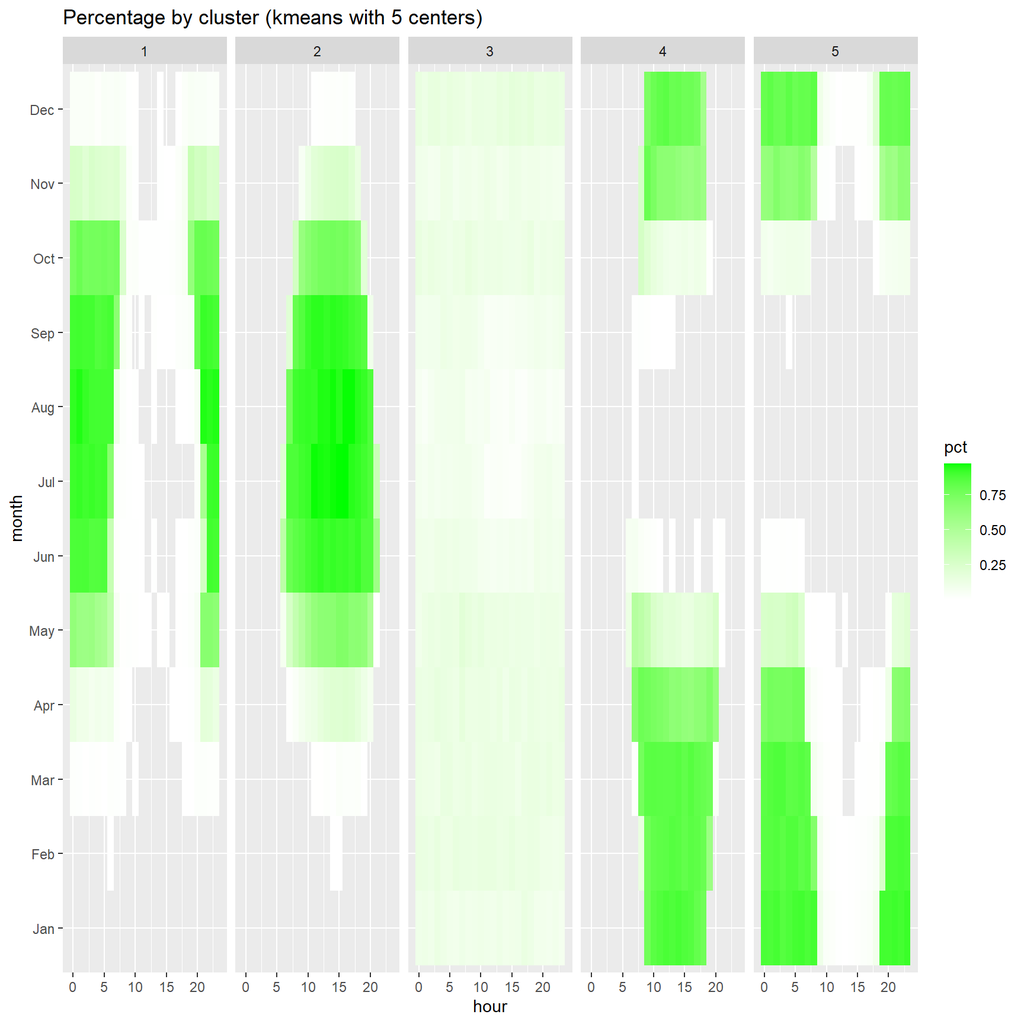

```r
# Function run on the 5-cluster k-means object
runKMeans(df=nycTempTrain,
          km=nycKMList[[5]],
          plotMeans=TRUE,
          plotPct=list(c("todSeason"), c("hour", "month")),
          nrowPct=1,
          nrowMeans=1
          )
```

```r
# Exploring precipitation by cluster
nycTempTrain %>%
    mutate(cl=nycKMList[[5]]$cluster) %>%
    group_by(cl) %>%
    summarize(n=n(),
              precip=sum(precipitation),
              rain=sum(rain),
              snow=sum(snowfall),
              pct_hrs_precip=mean(precipitation>0)
              ) %>%
    arrange(desc(precip))
```

```
## # A tibble: 5 × 6
##      cl     n precip   rain  snow pct_hrs_precip
##   <int> <int>  <dbl>  <dbl> <dbl>          <dbl>
## 1     3 10065 9901.  9066.  584.          0.965
## 2     2 21766 1018.  1018.    0           0.0711
## 3     1 17965  120.   120.    0           0.0150
## 4     5 20844  103.     1.6  81.8         0.0151
## 5     4 17812   48.5   16.8  28.8         0.0133
```

Clusters include precipitation/no, followed by the four quadrants of day/night and warm/cold season

Principal component analysis is run to explore variance explained by number of components:

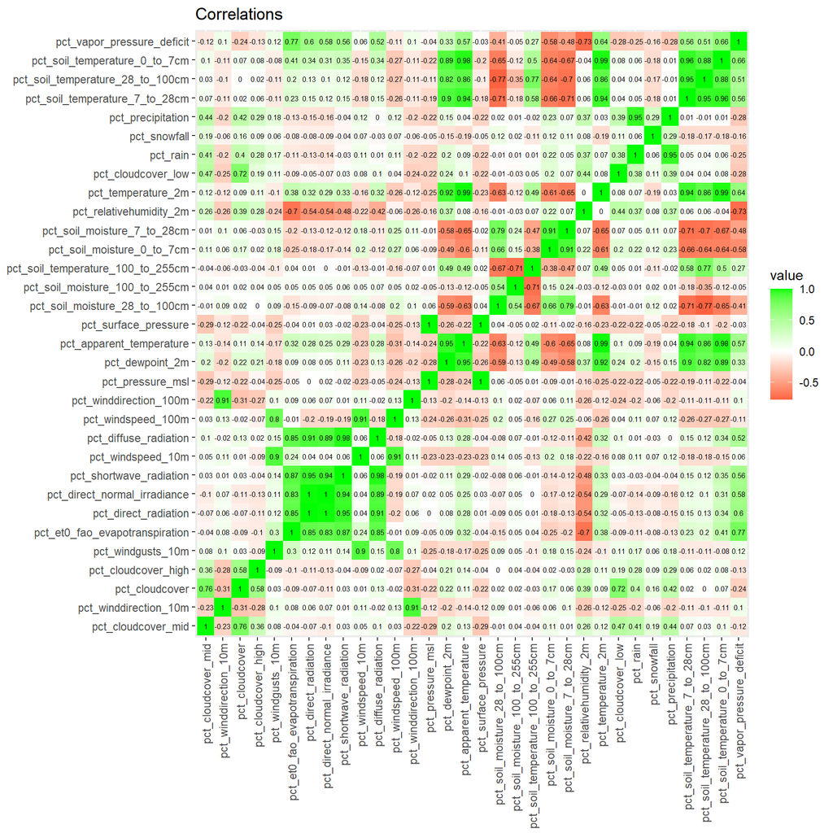

```r
# Correlation analysis
corTrain <- cor(nycTempTrain[, varsTrain])
hcTrain <- hclust(as.dist((1-corTrain)/2))
orderTrain <- hcTrain$order %>% purrr::set_names(hcTrain$labels)
tmpHeat <- as.data.frame(corTrain, row.names=rownames(corTrain)) %>%
    rownames_to_column("var1") %>%
    tibble::as_tibble() %>%
    pivot_longer(cols=-c("var1"), names_to="var2") %>%
    mutate()
tmpHeat %>%
    ggplot(aes(x=fct_reorder(var1, orderTrain[var1]), y=fct_reorder(var2, orderTrain[var2]))) +
    geom_tile(aes(fill=value)) +
    geom_text(aes(label=round(value, 2)), size=2) +
    scale_fill_gradient2(low="red", mid="white", high="green") +
    labs(x=NULL, y=NULL, title="Correlations") +
    theme(axis.text.x=element_text(angle=90, vjust=0.5, hjust=1))
```

```r
pcaTrain <- prcomp(nycTempTrain[, varsTrain])
summary(pcaTrain)
```

```
## Importance of components:
##                            PC1     PC2     PC3      PC4      PC5      PC6
## Standard deviation     92.9713 76.8021 66.0539 51.40618 40.00159 36.42079
## Proportion of Variance  0.2821  0.1925  0.1424  0.08625  0.05223  0.04329
## Cumulative Proportion   0.2821  0.4746  0.6170  0.70329  0.75552  0.79881
##                             PC7      PC8      PC9     PC10     PC11     PC12
## Standard deviation     33.96092 32.67399 29.09379 27.76099 24.21620 20.54141
## Proportion of Variance  0.03764  0.03484  0.02763  0.02515  0.01914  0.01377
## Cumulative Proportion   0.83646  0.87130  0.89893  0.92408  0.94322  0.95699
##                            PC13    PC14     PC15     PC16     PC17   PC18
## Standard deviation     14.33743 14.1073 13.59159 12.58364 10.51321 9.4187
## Proportion of Variance  0.00671  0.0065  0.00603  0.00517  0.00361 0.0029
## Cumulative Proportion   0.96370  0.9702  0.97623  0.98140  0.98500 0.9879
##                           PC19    PC20    PC21    PC22    PC23    PC24    PC25
## Standard deviation     8.59093 8.19193 7.54046 6.67977 5.94066 5.28136 4.33450
## Proportion of Variance 0.00241 0.00219 0.00186 0.00146 0.00115 0.00091 0.00061
## Cumulative Proportion  0.99031 0.99250 0.99436 0.99581 0.99696 0.99787 0.99849
##                           PC26    PC27    PC28    PC29    PC30    PC31   PC32
## Standard deviation     3.98204 3.86099 2.78793 2.07996 1.60886 0.88819 0.3374
## Proportion of Variance 0.00052 0.00049 0.00025 0.00014 0.00008 0.00003 0.0000
## Cumulative Proportion  0.99900 0.99949 0.99974 0.99989 0.99997 1.00000 1.0000
```

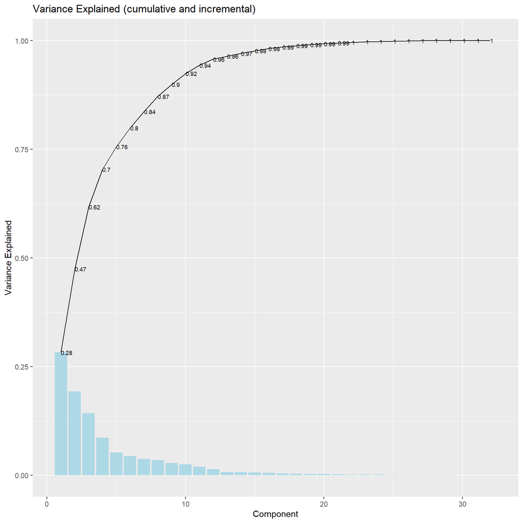

```r
tibble::tibble(sd=pcaTrain$sdev, var=sd**2, n=1:length(pcaTrain$sdev)) %>%
    ggplot(aes(x=n)) +
    geom_col(aes(y=var/sum(var)), fill="lightblue") +
    geom_text(aes(y=cumsum(var)/sum(var), label=round(cumsum(var)/sum(var), 2)), hjust=0, size=2.5) +
    geom_line(aes(y=cumsum(var)/sum(var))) +
    labs(x="Component", y="Variance Explained", title="Variance Explained (cumulative and incremental)")
```

Around 75% of variance is explained by the first 5 components, with around 90% explained by the first 10 components

A simple random forest classification is explored, for prediction of month:

```r
# Simple random forest model
rfTempTrainMonth <- ranger::ranger(month ~ .,
                                   data=nycTempTrain[, c('month', varsTrain)],
                                   importance = "impurity"
                                   )
rfTempTrainMonth
```

```
## Ranger result
##
## Call:
##  ranger::ranger(month ~ ., data = nycTempTrain[, c("month", varsTrain)],      importance = "impurity")
##
## Type:                             Classification
## Number of trees:                  500
## Sample size:                      88452
## Number of independent variables:  32
## Mtry:                             5
## Target node size:                 1
## Variable importance mode:         impurity
## Splitrule:                        gini
## OOB prediction error:             0.30 %
```

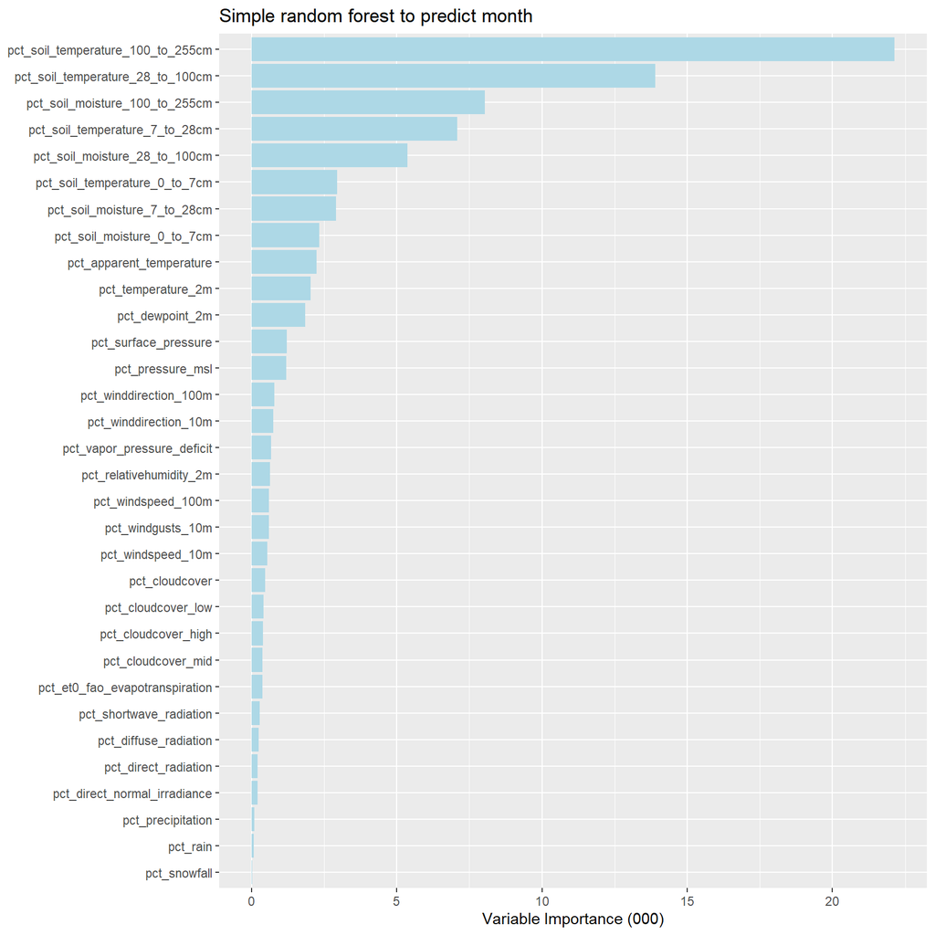

```r
# Variable importance
rfTempTrainMonth$variable.importance %>%
    as.data.frame() %>%
    purrr::set_names("imp") %>%
    rownames_to_column("metric") %>%
    tibble::as_tibble() %>%
    ggplot(aes(x=fct_reorder(metric, imp), y=imp/1000)) +
    geom_col(fill="lightblue") +
    labs(x=NULL, y="Variable Importance (000)", title="Simple random forest to predict month") +
    coord_flip()
```

```r
# Performance on test data (confirm >99% accuracy)
rfTempTest <- nycTempTest %>%
    mutate(pred=predict(rfTempTrainMonth, data=.)$predictions)
cat("\nAccuracy on test dataset is: ", round(100*mean(rfTempTest$pred==rfTempTest$month), 2), "%\n", sep="")
```

```
##
## Accuracy on test dataset is: 99.75%
```

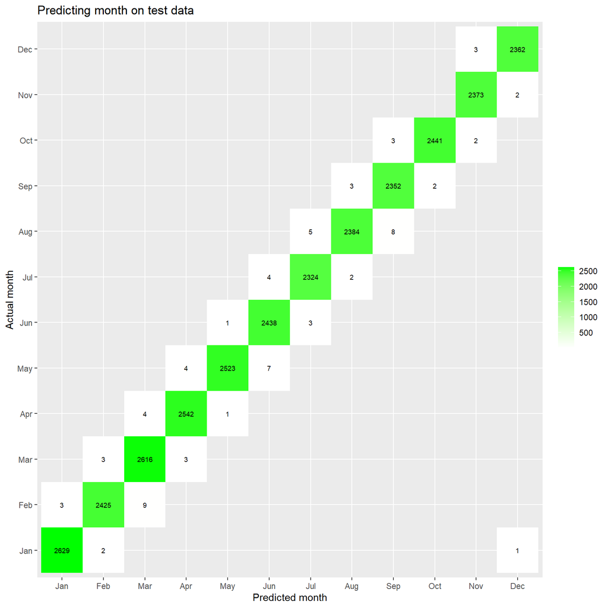

```r
rfTempTest %>%
    count(month, pred) %>%
    ggplot(aes(x=pred, y=month)) +
    geom_tile(aes(fill=n)) +
    geom_text(aes(label=n), size=2.5) +
    scale_fill_continuous("", low="white", high="green") +
    labs(x="Predicted month", y="Actual month", title="Predicting month on test data")
```

The simple random forest has over 99% predictive accuracy on month, primarily focusing on metrics related to soil (soil temperature and soil moisture at various depths).

A portion of the predictive accuracy may be based on specific soil trends during a given year, as it is very unlikely that data consistently change right at 00h00 of a new month. Models are run using a holdout year:

```r
# Simple random forest model, holding out 2022 data
rfTempHoldout <- ranger::ranger(month ~ .,
                                data=nycTempTrain[year(nycTempTrain$date) != 2022, c('month', varsTrain)],
                                importance = "impurity"
                                )
rfTempHoldout
```

```
## Ranger result
##
## Call:
##  ranger::ranger(month ~ ., data = nycTempTrain[year(nycTempTrain$date) !=      2022, c("month", varsTrain)], importance = "impurity")
##
## Type:                             Classification
## Number of trees:                  500
## Sample size:                      81858
## Number of independent variables:  32
## Mtry:                             5
## Target node size:                 1
## Variable importance mode:         impurity
## Splitrule:                        gini
## OOB prediction error:             0.29 %
```

```r
# Performance on holdout data
rfTempTest <- nycTempTrain %>%
    bind_rows(nycTempTest) %>%
    filter(year(date)==2022) %>%
    mutate(pred=predict(rfTempHoldout, data=.)$predictions)
cat("\nAccuracy on holdout 2022 data is: ", round(100*mean(rfTempTest$pred==rfTempTest$month), 2), "%\n", sep="")
```

```
##
## Accuracy on holdout 2022 data is: 82.32%
```

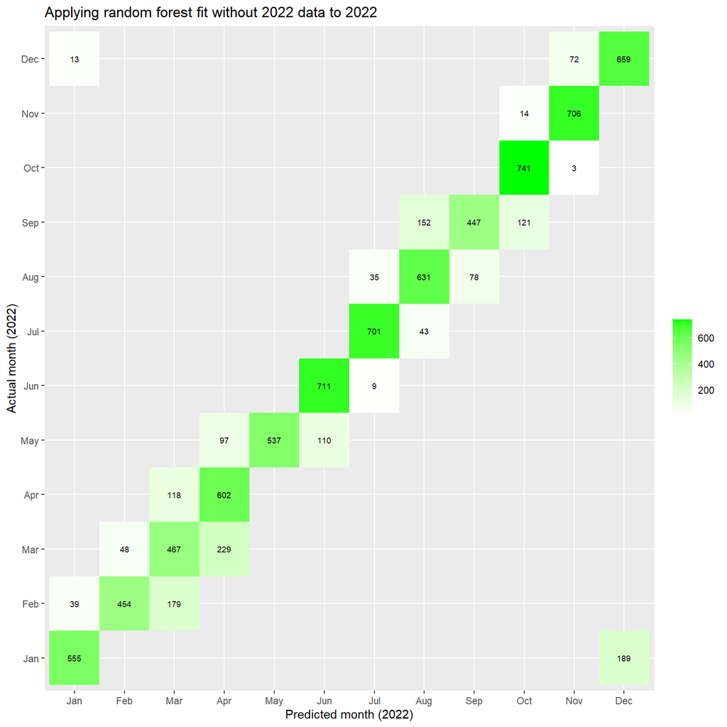

```r
rfTempTest %>%
    count(month, pred) %>%
    ggplot(aes(x=pred, y=month)) +
    geom_tile(aes(fill=n)) +
    geom_text(aes(label=n), size=2.5) +
    scale_fill_continuous("", low="white", high="green") +
    labs(x="Predicted month (2022)",
         y="Actual month (2022)",
         title="Applying random forest fit without 2022 data to 2022"
         )
```

Without access to training data including 2022, the model still makes good predictions for 2022 month. But, predictions are commonly off by +/- 1 month leading to overall accuracy of ~80% (vs. 99%+ when able to train on soil heating patterns in the given year)

The process for running random forest is converted to functional form:

```r
runSimpleRF <- function(df, yVar, xVars=NULL, ...) {

    # FUNCTION ARGUMENTS:
    # df: data frame containing observations
    # yVar: variable to be predicted (numeric for regression, categorical for classification)
    # xVars: predictor variables (NULL means everything in df except for yVar)
    # ...: other arguments passed to ranger::ranger

    # Create xVars if passed as NULL
    if(is.null(xVars)) xVars <- setdiff(names(df), yVar)

    # Simple random forest model
    ranger::ranger(as.formula(paste0(yVar, "~", paste0(xVars, collapse="+"))),
                   data=df[, c(yVar, xVars)],
                   ...
                   )

}
```

The function is checked for consistency:

```r
tstRF <- runSimpleRF(df=nycTempTrain, yVar="month", xVars=varsTrain, importance="impurity")
tstRF
```

```
## Ranger result
##
## Call:
##  ranger::ranger(as.formula(paste0(yVar, "~", paste0(xVars, collapse = "+"))),      data = df[, c(yVar, xVars)], ...)
##
## Type:                             Classification
## Number of trees:                  500
## Sample size:                      88452
## Number of independent variables:  32
## Mtry:                             5
## Target node size:                 1
## Variable importance mode:         impurity
## Splitrule:                        gini
## OOB prediction error:             0.28 %
```

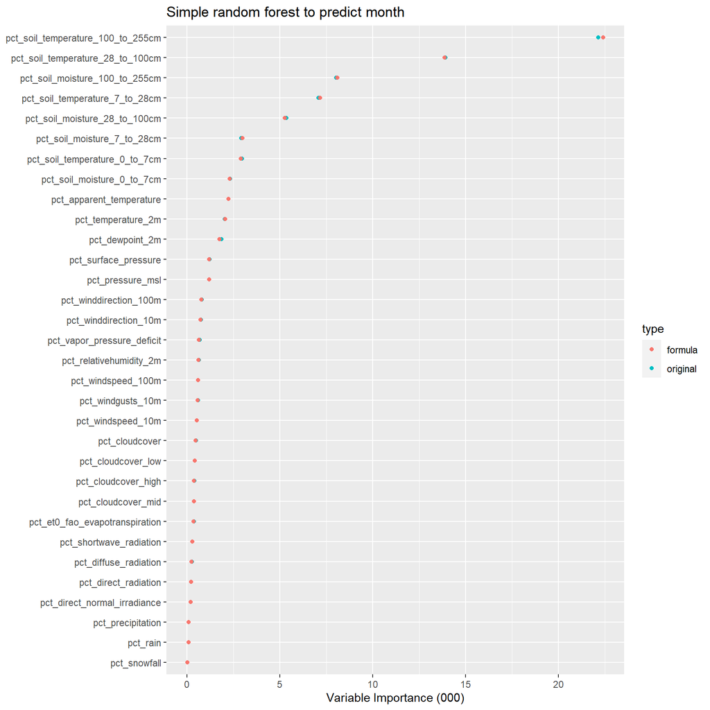

```r
# Comparison of variable importance
rfTempTrainMonth$variable.importance %>%
    as.data.frame() %>%
    purrr::set_names("imp") %>%
    rownames_to_column("metric") %>%
    tibble::as_tibble() %>%
    mutate(type="original") %>%
    bind_rows(tstRF$variable.importance %>%
                  as.data.frame() %>%
                  purrr::set_names("imp") %>%
                  rownames_to_column("metric") %>%
                  tibble::as_tibble() %>%
                  mutate(type="formula")
              ) %>%
    ggplot(aes(x=fct_reorder(metric, imp), y=imp/1000)) +
    geom_point(aes(color=type)) +
    labs(x=NULL, y="Variable Importance (000)", title="Simple random forest to predict month") +
    coord_flip()
```

Aside from minor differences due to different random conditions (no seed was set prior to either run), the function and original call produce substantially the same outputs

A function is written for plotting variable importance:

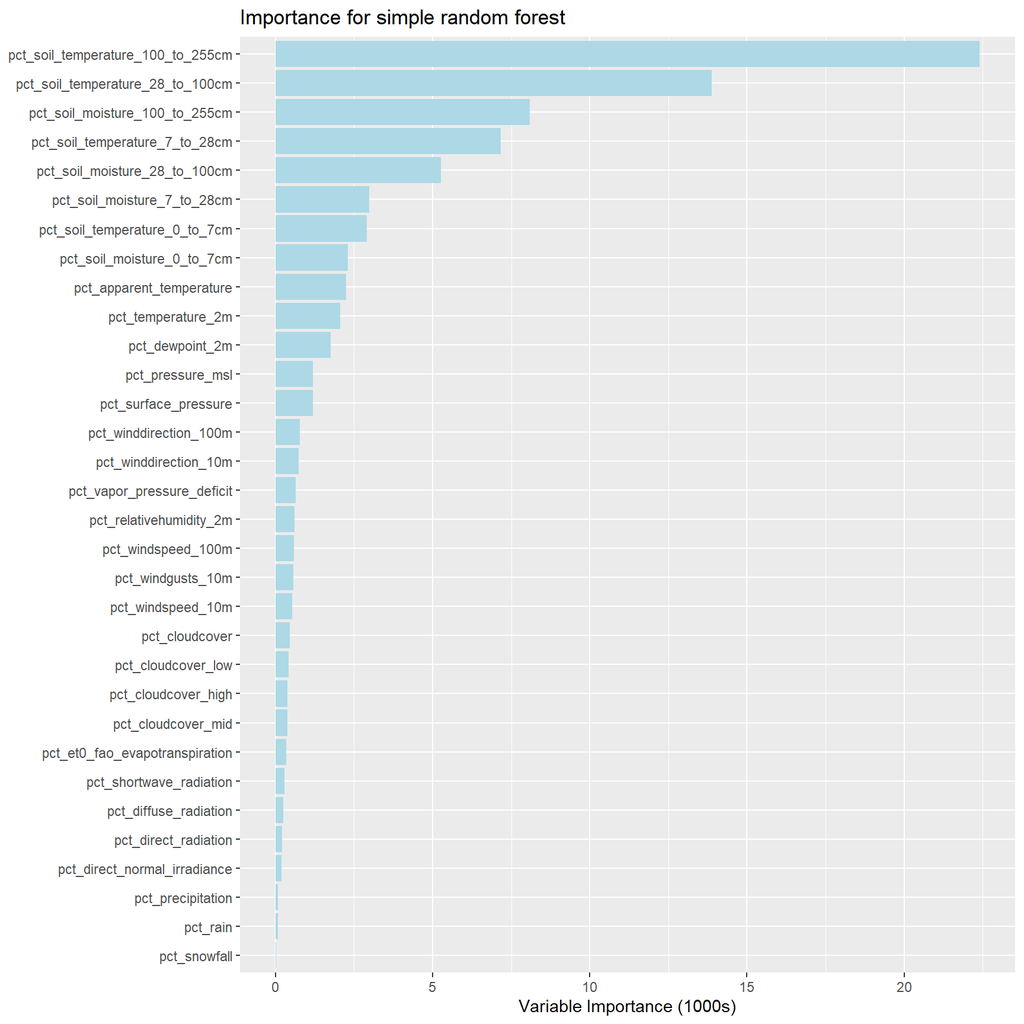

```r
plotRFImportance <- function(rf,
                             impName="variable.importance",
                             divBy=1000,
                             plotTitle=NULL,
                             plotData=TRUE,
                             returnData=!isTRUE(plotData)
                             ) {

    # FUNCTION ARGUMENTS:
    # rf: output list from random forest with an element for importance
    # impName: name of the element to extract from rf
    # divBy: divisor for the importance variable
    # plotTitle: title for plot (NULL means use default)
    # plotData: boolean, should the importance plot be created and printed?
    # returnData: boolean, should the processed data be returned?

    # Create title if not provided
    if(is.null(plotTitle)) plotTitle <- "Importance for simple random forest"

    # Create y-axis label
    yAxisLabel="Variable Importance"
    if(!isTRUE(all.equal(divBy, 1))) yAxisLabel <- paste0(yAxisLabel, " (", divBy, "s)")

    # Create variable importance
    df <- rf[[impName]] %>%
        as.data.frame() %>%
        purrr::set_names("imp") %>%
        rownames_to_column("metric") %>%
        tibble::as_tibble()

    # Create and print plot if requested
    if(isTRUE(plotData)) {
        p1 <- df %>%
            ggplot(aes(x=fct_reorder(metric, imp), y=imp/divBy)) +
            geom_col(fill="lightblue") +
            labs(x=NULL, y=yAxisLabel, title=plotTitle) +
            coord_flip()
        print(p1)
    }

    # Return data if requested
    if(isTRUE(returnData)) return(df)

}

# Example for plot only
plotRFImportance(tstRF)
```

```r
# Example for data only
plotRFImportance(tstRF, plotData=FALSE)
```

```
## # A tibble: 32 × 2
##    metric                      imp
##    <chr>                     <dbl>
##  1 pct_temperature_2m       2053.
##  2 pct_relativehumidity_2m   613.
##  3 pct_dewpoint_2m          1758.
##  4 pct_apparent_temperature 2240.
##  5 pct_pressure_msl         1186.
##  6 pct_surface_pressure     1185.
##  7 pct_precipitation          89.5
##  8 pct_rain                   82.4
##  9 pct_snowfall               20.9
## 10 pct_cloudcover            461.
## # … with 22 more rows
```

A function is written for applying the model to test (or other) data:

```r
# Ranger needs to be explicitly in the namespace for predictions
library(ranger)

predictRF <- function(rf, df, newCol="pred", predsOnly=FALSE) {

    # FUNCTION ARGUMENTS:
    # rf: a trained random forest model
    # df: data frame for adding predictions
    # newCol: name for new column to be added to df
    # predsOnly: boolean, should only the vector of predictions be returned?
    #            if FALSE, a column named newCol is added to df, with df returned

    # Performance on holdout data
    preds <- predict(rf, data=df)$predictions

    # Return just the predictions if requested otherwise add as final column to df
    if(isTRUE(predsOnly)) return(preds)
    else {
        df[newCol] <- preds
        return(df)
    }

}

# Predictions only
summary(predictRF(rf=tstRF, df=nycTempTest, predsOnly=TRUE))
```

```
##  Jan  Feb  Mar  Apr  May  Jun  Jul  Aug  Sep  Oct  Nov  Dec
## 2629 2435 2628 2547 2525 2449 2332 2390 2361 2446 2375 2367
```

```r
# Full data frame
glimpse(predictRF(rf=tstRF, df=nycTempTest))
```

```
## Rows: 29,484
## Columns: 85
## $ time                              <dttm> 2010-01-01 00:00:00, 2010-01-01 01:…
## $ date                              <date> 2010-01-01, 2010-01-01, 2010-01-01,…
## $ hour                              <int> 0, 1, 4, 16, 22, 1, 3, 5, 6, 7, 9, 2…
## $ temperature_2m                    <dbl> -1.1, -1.0, -0.9, 5.0, -1.2, -1.2, -…
## $ relativehumidity_2m               <int> 95, 96, 97, 72, 89, 87, 77, 72, 72, …
## $ dewpoint_2m                       <dbl> -1.7, -1.6, -1.3, 0.4, -2.8, -3.0, -…
## $ apparent_temperature              <dbl> -3.9, -3.9, -3.7, 2.2, -5.1, -6.2, -…
## $ pressure_msl                      <dbl> 1017.2, 1016.5, 1015.6, 1010.3, 1008…
## $ surface_pressure                  <dbl> 1012.6, 1011.9, 1011.0, 1005.8, 1003…
## $ precipitation                     <dbl> 0.5, 0.5, 0.1, 0.0, 0.0, 0.2, 0.0, 0…
## $ rain                              <dbl> 0.0, 0.1, 0.0, 0.0, 0.0, 0.0, 0.0, 0…
## $ snowfall                          <dbl> 0.35, 0.28, 0.07, 0.00, 0.00, 0.14, …
## $ cloudcover                        <int> 90, 93, 71, 100, 94, 100, 100, 100, …
```

[output cut: 72 more lines]

A function is written to report accuracy:

```r
reportAccuracy <- function(df,
                           trueCol,
                           predCol="pred",
                           reportAcc=TRUE,
                           rndReport=2,
                           useLabel="requested data",
                           returnAcc=!isTRUE(reportAcc)
                           ) {

    # FUNCTION ARGUMENTS:
    # df: data frame containing actual and predictions
    # trueCol: column containing true value
    # predCol: column containing predicted value
    # reportAcc: boolean, should accuracy be reported (printed to output)?
    # rndReport: number of significant digits for reporting (will be converted to percentage first)
    # useLabel: label for data to be used in reporting
    # returnAcc: boolean, should the accuracy be returned
    #            return value is not converted to percentage, not rounded

    # For now, implemented only for categorical
    acc <- mean(df[trueCol]==df[predCol])

    # Report accuracy if requested
    if(isTRUE(reportAcc)) cat("\nAccuracy of ", useLabel, " is: ", round(100*acc, rndReport), "%\n", sep="")

    # Return accuracy statistic if requested
    if(isTRUE(returnAcc)) return(acc)

}

reportAccuracy(predictRF(rf=tstRF, df=nycTempTest), trueCol="month")
```

```
##
## Accuracy of requested data is: 99.76%
```

```r
reportAccuracy(predictRF(rf=tstRF, df=nycTempTest),
               trueCol="month",
               rndReport=3,
               useLabel="predictions applied to test dataset",
               returnAcc=TRUE
               )
```

```
##
## Accuracy of predictions applied to test dataset is: 99.763%
```

```
## [1] 0.9976258
```

A function is written to plot confusion:

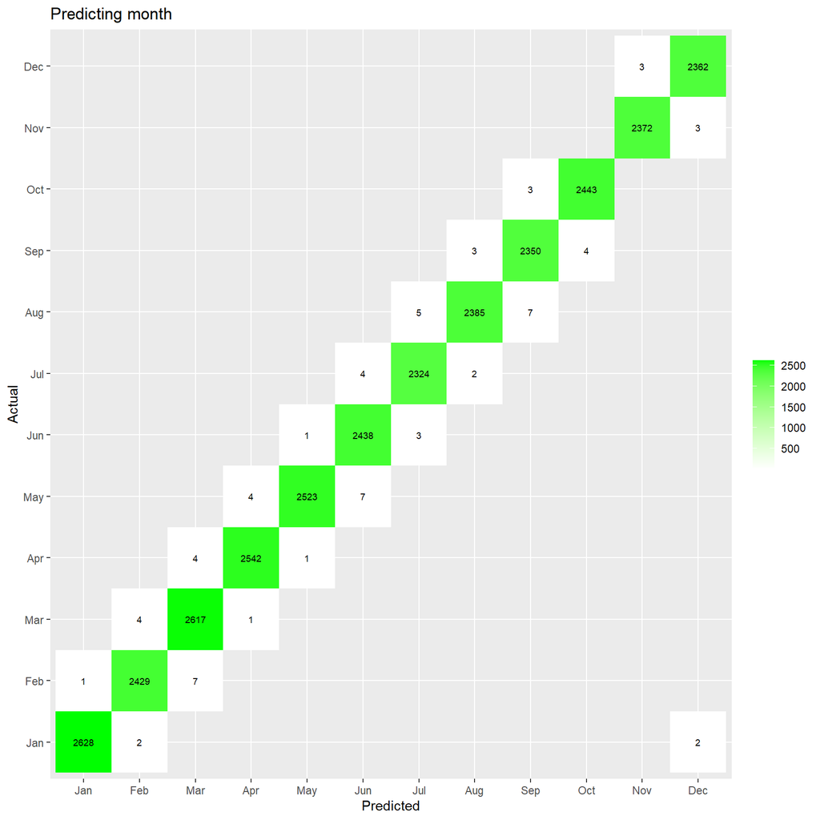

```r
plotConfusion <- function(df,
                          trueCol,
                          predCol="pred",
                          useTitle=NULL,
                          useSub=NULL
                           ) {

    # FUNCTION ARGUMENTS:
    # df: data frame containing actual and predictions
    # trueCol: column containing true value
    # predCol: column containing predicted value
    # useTitle: title to be used for chart (NULL means create from trueCol)
    # useSub: subtitle to be used for chart (NULL means none)

    # Create title if not supplied
    if(is.null(useTitle)) useTitle <- paste0("Predicting ", trueCol)

    # Confusion matrix (categorical)
    p1 <- df %>%
        group_by(across(all_of(c(trueCol, predCol)))) %>%
        summarize(n=n(), .groups="drop") %>%
        ggplot(aes(x=get(predCol), y=get(trueCol))) +
        geom_tile(aes(fill=n)) +
        geom_text(aes(label=n), size=2.5) +
        scale_fill_continuous("", low="white", high="green") +
        labs(x="Predicted", y="Actual", title=useTitle, subtitle=useSub)
    print(p1)

}

plotConfusion(predictRF(rf=tstRF, df=nycTempTest), trueCol="month")
```

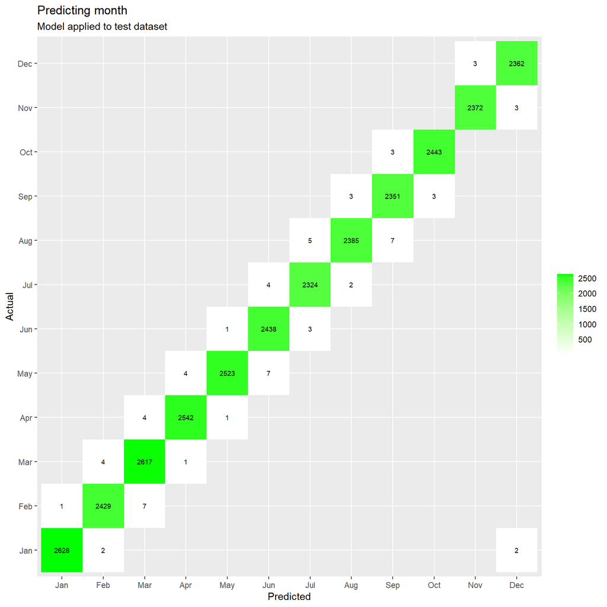

```r
plotConfusion(predictRF(rf=tstRF, df=nycTempTest), trueCol="month", useSub="Model applied to test dataset")
```

Functions are run to build the same random forest excluding 2023 data, and with 2022 as a holdout year:

```r
# 1. Run random forest
tstRFHoldout <- runSimpleRF(df=filter(nycTempTrain, lubridate::year(date)<2022),
                            yVar="month",
                            xVars=varsTrain,
                            importance="impurity"
                            )
tstRFHoldout
```

```
## Ranger result
##
## Call:
##  ranger::ranger(as.formula(paste0(yVar, "~", paste0(xVars, collapse = "+"))),      data = df[, c(yVar, xVars)], ...)
##
## Type:                             Classification
## Number of trees:                  500
## Sample size:                      78907
## Number of independent variables:  32
## Mtry:                             5
## Target node size:                 1
## Variable importance mode:         impurity
## Splitrule:                        gini
## OOB prediction error:             0.29 %
```

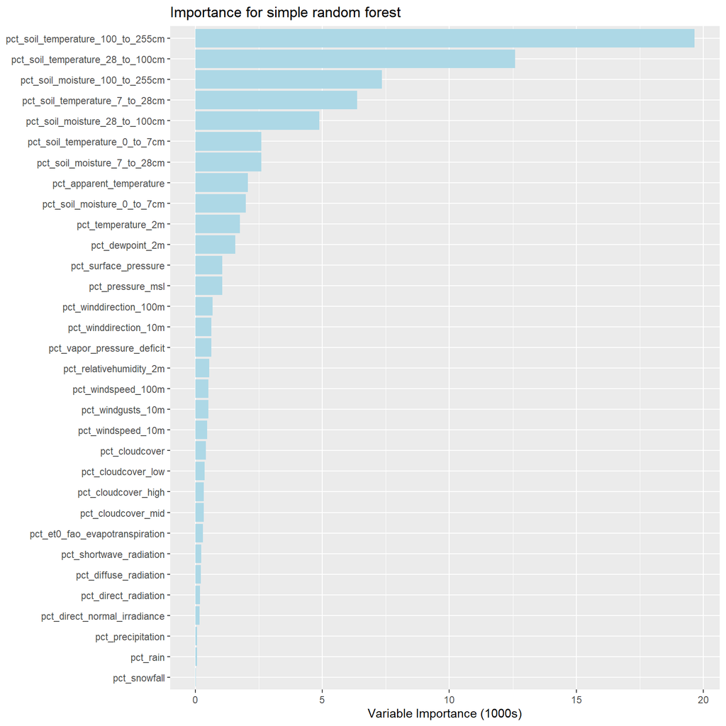

```r
# 2. Plot variable importance
plotRFImportance(tstRFHoldout)
```

```r
# 3. Predict on year 2022
tstRFPred <- predictRF(rf=tstRFHoldout,
                       df=filter(bind_rows(nycTempTest, nycTempTrain), lubridate::year(date)==2022))
tstRFPred
```

```
## # A tibble: 8,760 × 85
##    time                date        hour temper…¹ relat…² dewpo…³ appar…⁴ press…⁵
##    <dttm>              <date>     <int>    <dbl>   <int>   <dbl>   <dbl>   <dbl>
##  1 2022-01-01 01:00:00 2022-01-01     1      8.9      98     8.6     7.4   1013.
##  2 2022-01-01 02:00:00 2022-01-01     2      8.8      98     8.5     7.4   1013.
##  3 2022-01-01 03:00:00 2022-01-01     3      8.9      99     8.7     7.9   1012.
##  4 2022-01-01 13:00:00 2022-01-01    13     11.3      96    10.7    11     1008.
##  5 2022-01-01 14:00:00 2022-01-01    14     12.1      93    11      11.6   1008.
##  6 2022-01-01 18:00:00 2022-01-01    18     10.8      99    10.7    10     1006.
##  7 2022-01-01 23:00:00 2022-01-01    23      9.9      99     9.7     8.7   1003.
##  8 2022-01-02 01:00:00 2022-01-02     1      9.7      98     9.4     8.3   1002.
##  9 2022-01-02 02:00:00 2022-01-02     2      9.7      97     9.3     7.9   1000.
## 10 2022-01-02 17:00:00 2022-01-02    17     11        87     9       9.1   1006.
## # … with 8,750 more rows, 77 more variables: surface_pressure <dbl>,
## #   precipitation <dbl>, rain <dbl>, snowfall <dbl>, cloudcover <int>,
## #   cloudcover_low <int>, cloudcover_mid <int>, cloudcover_high <int>,
## #   shortwave_radiation <dbl>, direct_radiation <dbl>,
## #   direct_normal_irradiance <dbl>, diffuse_radiation <dbl>,
## #   windspeed_10m <dbl>, windspeed_100m <dbl>, winddirection_10m <int>,
## #   winddirection_100m <int>, windgusts_10m <dbl>, …
```

```r
# 4. Report on accuracy
reportAccuracy(tstRFPred,
               trueCol="month",
               rndReport=3,
               useLabel="predictions based on pre-2022 training data applied to 2022 holdout dataset"
               )
```

```
##
## Accuracy of predictions based on pre-2022 training data applied to 2022 holdout dataset is: 83.642%
```

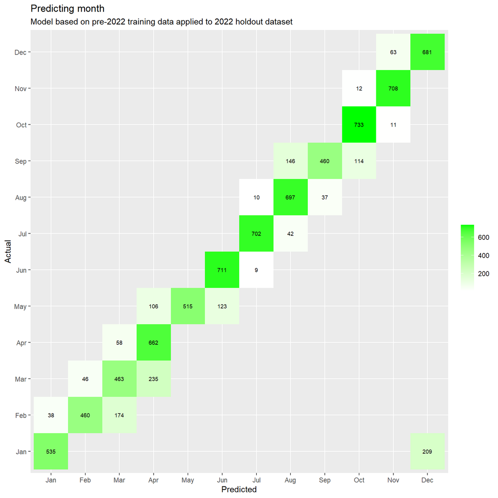

```r
# 5. Plot confusion data
plotConfusion(tstRFPred,
              trueCol="month",
              useSub="Model based on pre-2022 training data applied to 2022 holdout dataset"
              )
```

The model learns generalized trends, recording ~80% accuracy (always within +/- 1 month) for predictions applied to 2022 holdout data. Some of what the model learns is specific to one or more years in the non-holdout training dataset, accounting for >99% OOB accuracy in training data falling to ~80% accuracy in a holdout year

A main function is created for running all steps:

```r
runFullRF <- function(dfTrain,
                      yVar,
                      xVars,
                      dfTest=dfTrain,
                      useLabel="test data",
                      useSub=NULL,
                      returnData=FALSE
                      ) {

    # FUNCTION ARGUMENTS:
    # dfTrain: training data
    # yVar: dependent variable
    # xVars: column(s) containing independent variables
    # dfTest: test dataset for applying predictions
    # useLabel: label to be used for reporting accuracy
    # useSub: subtitle to be used for confusion chart (NULL means none)
    # returnData: boolean, should data be returned?

    # 1. Run random forest using impurity for importance
    rf <- runSimpleRF(df=dfTrain, yVar=yVar, xVars=xVars, importance="impurity")

    # 2. Plot variable importance
    rfImp <- plotRFImportance(rf, returnData=TRUE)

    # 3. Predict on test dataset
    tstPred <- predictRF(rf=rf, df=dfTest)

    # 4. Report on accuracy
    rfAcc <- reportAccuracy(tstPred, trueCol=yVar, rndReport=3, useLabel=useLabel, returnAcc=TRUE)

    # 5. Plot confusion data
    plotConfusion(tstPred, trueCol=yVar, useSub=useSub)

    #6. Return data if requested
    if(isTRUE(returnData)) return(list(rf=rf, rfImp=rfImp, tstPred=tstPred, rfAcc=rfAcc))

}
```

The function is tested:

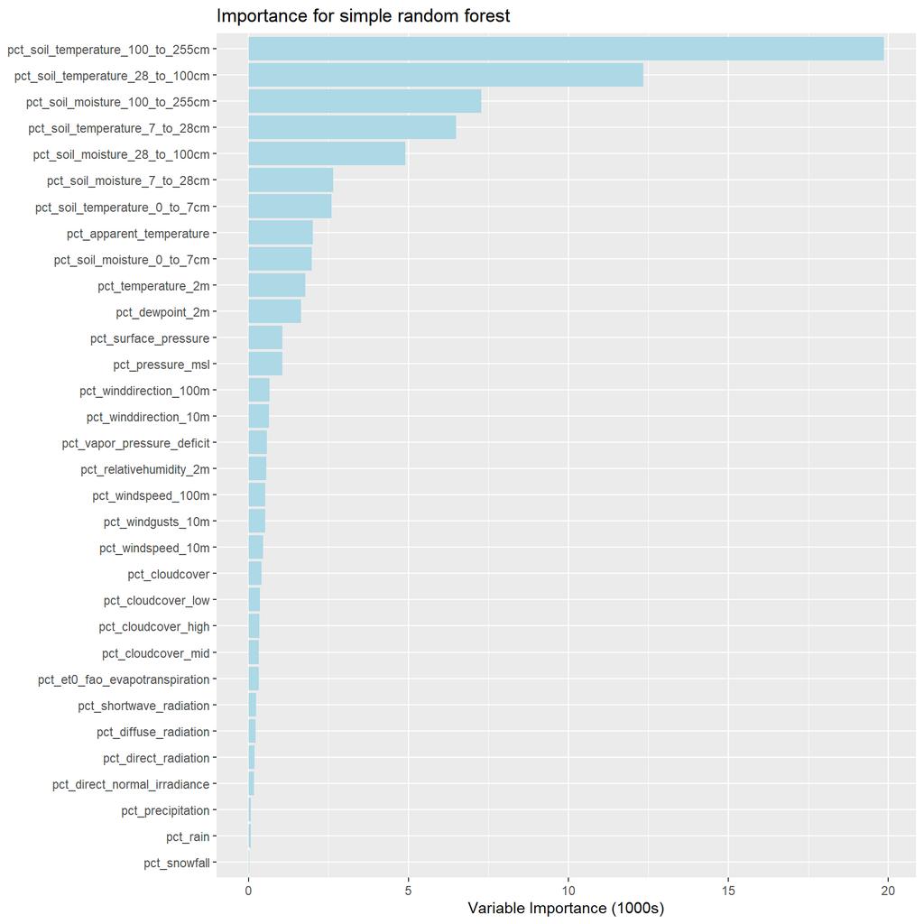

```
##
## Accuracy of predictions based on pre-2022 training data applied to 2022 holdout dataset is: 82.991%
```

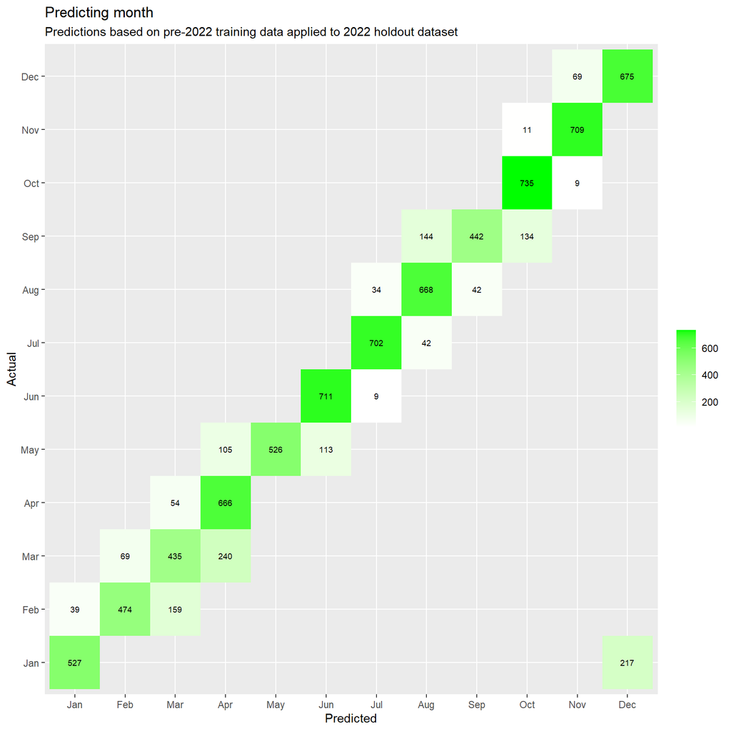

```r
dfTrain <- filter(nycTempTrain, lubridate::year(date)<2022)
dfTest <- filter(bind_rows(nycTempTest, nycTempTrain), lubridate::year(date)==2022)
keyLabel <- "predictions based on pre-2022 training data applied to 2022 holdout dataset"

runFullRF(dfTrain=dfTrain,
          yVar="month",
          xVars=varsTrain,
          dfTest=dfTest,
          useLabel=keyLabel,
          useSub=stringr::str_to_sentence(keyLabel)
          )
```

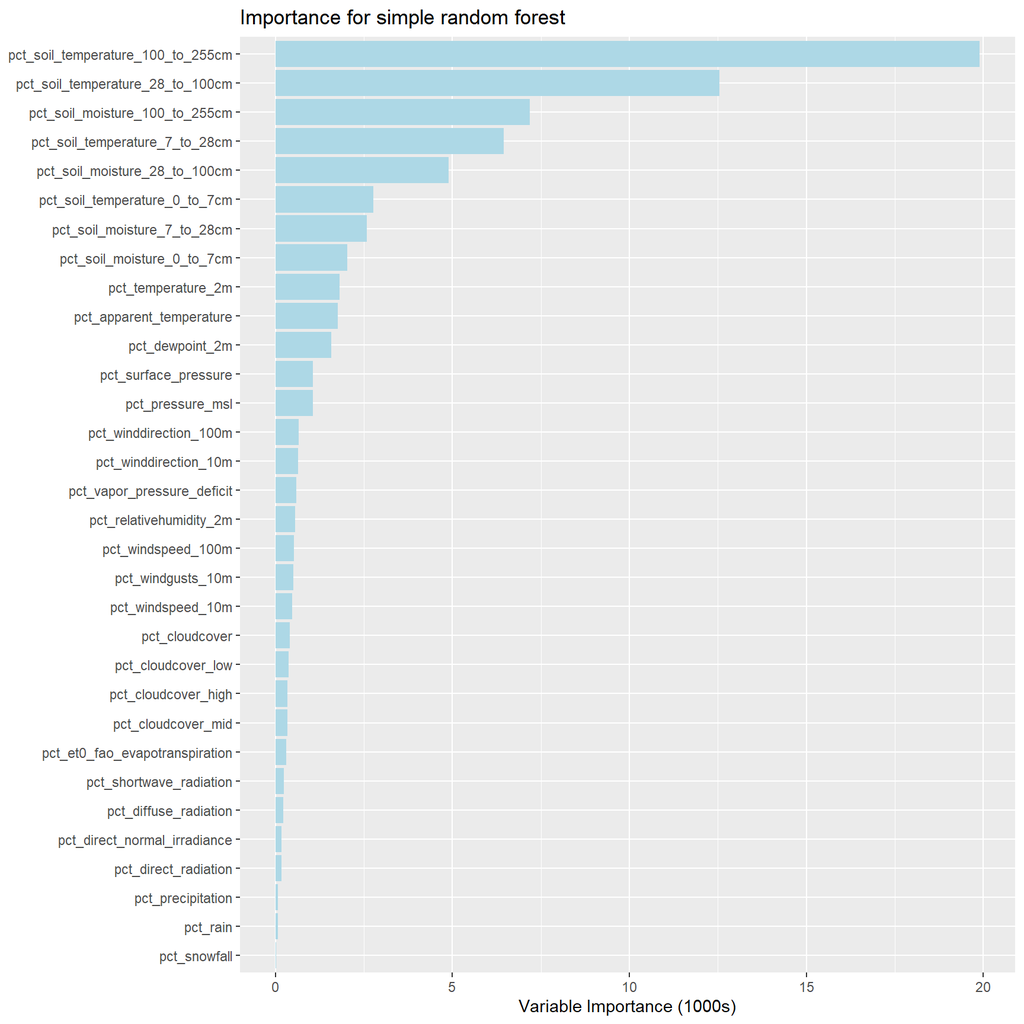

```
##
## Accuracy of predictions based on pre-2022 training data applied to 2022 holdout dataset is: 83.368%
```

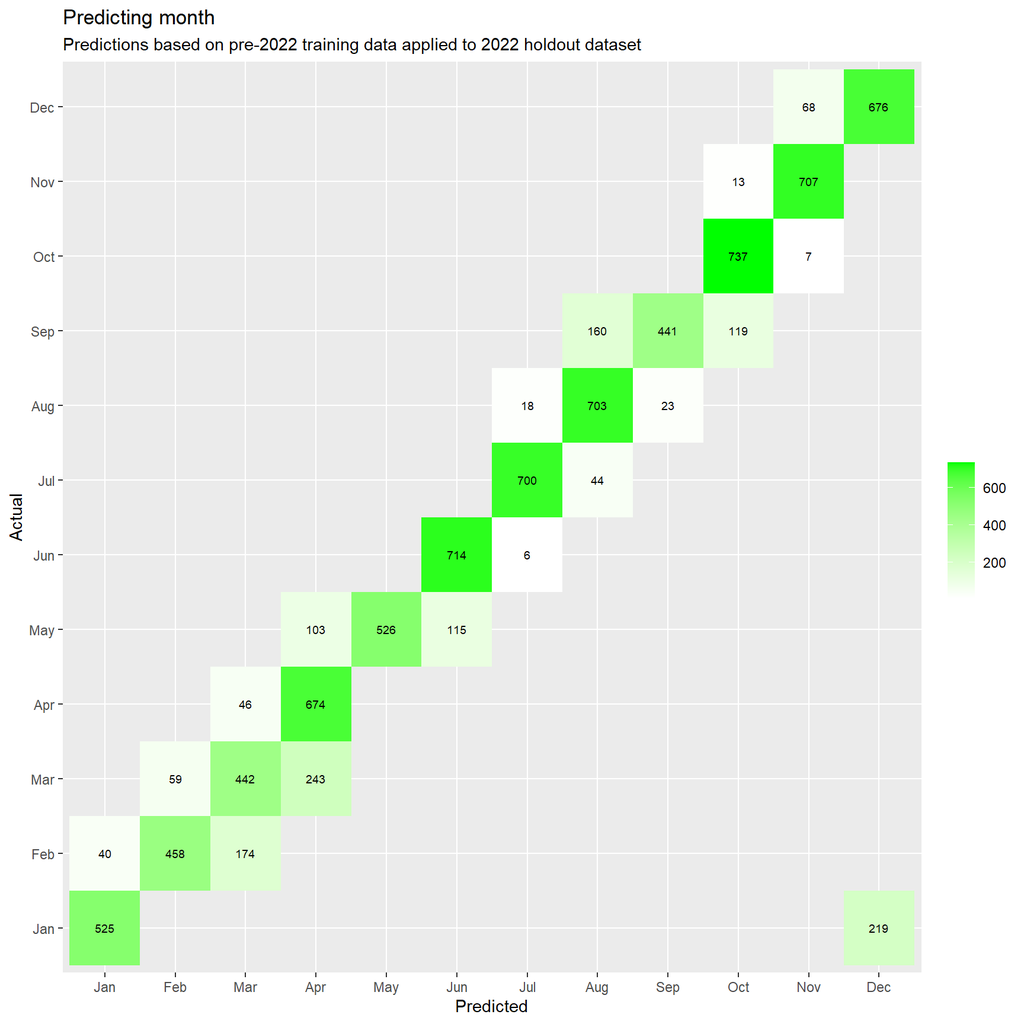

```
## List of 4
##  $ rf     :List of 15
##   ..$ predictions              : Factor w/ 12 levels "Jan","Feb","Mar",..: 1 1 1 1 1 1 1 1 1 1 ...
##   ..$ num.trees                : num 500
##   ..$ num.independent.variables: num 32
##   ..$ mtry                     : num 5
##   ..$ min.node.size            : num 1
##   ..$ variable.importance      : Named num [1:32] 1815 550 1575 1757 1052 ...
##   .. ..- attr(*, "names")= chr [1:32] "pct_temperature_2m" "pct_relativehumidity_2m" "pct_dewpoint_2m" "pct_apparent_temperature" ...
##   ..$ prediction.error         : num 0.00284
##   ..$ forest                   :List of 9
##   .. ..$ num.trees                 : num 500
##   .. ..$ child.nodeIDs             :List of 500
##   .. ..$ split.varIDs              :List of 500
##   .. ..$ split.values              :List of 500
##   .. ..$ is.ordered                : logi [1:32] TRUE TRUE TRUE TRUE TRUE TRUE ...
##   .. ..$ class.values              : num [1:12] 1 2 3 4 5 6 7 8 9 10 ...
##   .. ..$ levels                    : chr [1:12] "Jan" "Feb" "Mar" "Apr" ...
##   .. ..$ independent.variable.names: chr [1:32] "pct_temperature_2m" "pct_relativehumidity_2m" "pct_dewpoint_2m" "pct_apparent_temperature" ...
##   .. ..$ treetype                  : chr "Classification"
##   .. ..- attr(*, "class")= chr "ranger.forest"
##   ..$ confusion.matrix         : 'table' int [1:12, 1:12] 6676 7 0 0 0 0 0 0 0 0 ...
##   .. ..- attr(*, "dimnames")=List of 2
##   ..$ splitrule                : chr "gini"
##   ..$ treetype                 : chr "Classification"
##   ..$ call                     : language ranger::ranger(as.formula(paste0(yVar, "~", paste0(xVars, collapse = "+"))),      data = df[, c(yVar, xVars)], ...)
##   .. ..- attr(*, "srcref")= 'srcref' int [1:8] 14 5 17 20 5 20 14 17
##   .. .. ..- attr(*, "srcfile")=Classes 'srcfilecopy', 'srcfile' <environment: 0x00000147c3626ac0>
##   ..$ importance.mode          : chr "impurity"
##   ..$ num.samples              : int 78907
##   ..$ replace                  : logi TRUE
##   ..- attr(*, "class")= chr "ranger"
##  $ rfImp  : tibble [32 × 2] (S3: tbl_df/tbl/data.frame)
##   ..$ metric: chr [1:32] "pct_temperature_2m" "pct_relativehumidity_2m" "pct_dewpoint_2m" "pct_apparent_temperature" ...
##   ..$ imp   : num [1:32] 1815 550 1575 1757 1052 ...
##  $ tstPred: tibble [8,760 × 85] (S3: tbl_df/tbl/data.frame)
##   ..$ time                             : POSIXct[1:8760], format: "2022-01-01 01:00:00" "2022-01-01 02:00:00" ...
##   ..$ date                             : Date[1:8760], format: "2022-01-01" "2022-01-01" ...
##   ..$ hour                             : int [1:8760] 1 2 3 13 14 18 23 1 2 17 ...
##   ..$ temperature_2m                   : num [1:8760] 8.9 8.8 8.9 11.3 12.1 10.8 9.9 9.7 9.7 11 ...
```

[output cut: 67 more lines]

```
##   ..$ pct_soil_moisture_28_to_100cm    : num [1:8760] 69 69 69 69 69 69 70 78 79 88 ...
##   ..$ pct_soil_moisture_100_to_255cm   : num [1:8760] 51 51 51 51 51 51 51 51 51 51 ...
##   ..$ pct_0005                         : int [1:8760] 0 5 3 2 5 3 2 4 4 5 ...
##   ..$ pct_0025                         : int [1:8760] 10 1 17 5 0 17 13 3 5 5 ...
##   ..$ pct_0100                         : int [1:8760] 83 58 19 95 23 92 5 69 36 76 ...
##   ..$ pct_0250                         : int [1:8760] 125 18 126 116 191 166 200 1 15 231 ...
##   ..$ pct_0500                         : int [1:8760] 427 344 218 133 186 290 333 129 465 319 ...
##   ..$ pct_1000                         : int [1:8760] 916 180 999 46 239 897 756 157 259 59 ...
##   ..$ pct_2500                         : int [1:8760] 1934 1910 1837 1519 2238 912 1747 1417 1977 1 ...
##   ..$ pct_5000                         : int [1:8760] 430 2032 1112 1432 1565 3262 124 786 475 2732 ...
##   ..$ tod                              : Factor w/ 2 levels "Day","Night": 2 2 2 1 1 1 2 2 2 1 ...
##   ..$ season                           : Factor w/ 4 levels "Spring","Summer",..: 4 4 4 4 4 4 4 4 4 4 ...
##   ..$ todSeason                        : Factor w/ 8 levels "Spring-Day","Spring-Night",..: 8 8 8 7 7 7 8 8 8 7 ...
##   ..$ pred                             : Factor w/ 12 levels "Jan","Feb","Mar",..: 12 12 12 12 12 12 12 12 12 12 ...
##  $ rfAcc  : num 0.834
```

```r
runFullRF(dfTrain=dfTrain,
          yVar="month",
          xVars=varsTrain,
          dfTest=dfTest,
          useLabel=keyLabel,
          useSub=stringr::str_to_sentence(keyLabel),
          returnData=TRUE
          ) %>%
    str(max.level=3)
```

The function is run for hour as a factor:

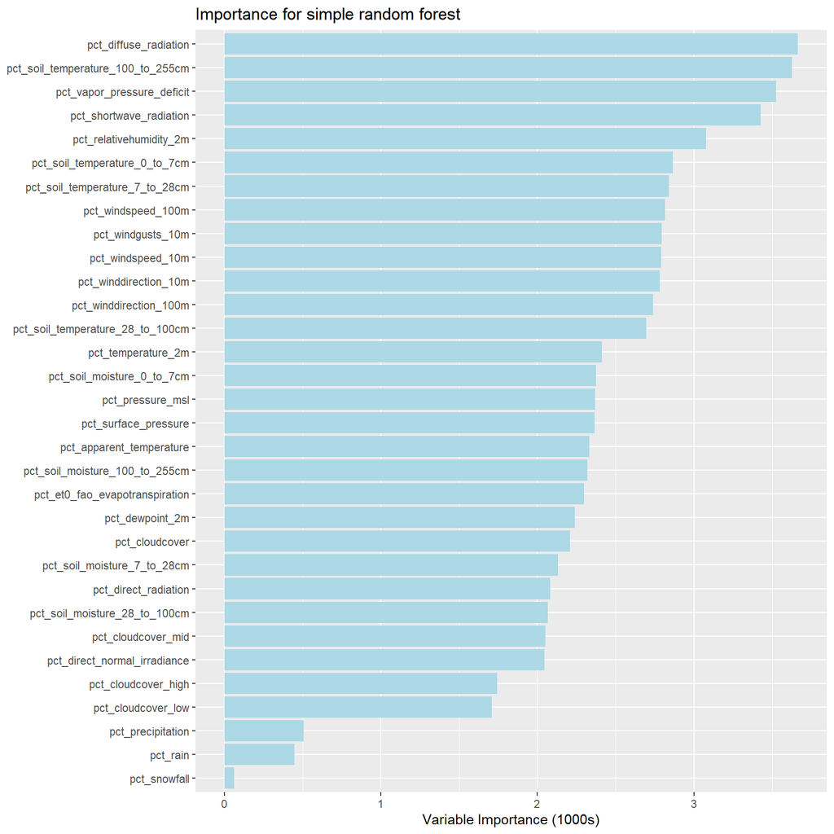

```
##
## Accuracy of predictions based on pre-2022 training data applied to 2022 holdout dataset is: 39.966%
```

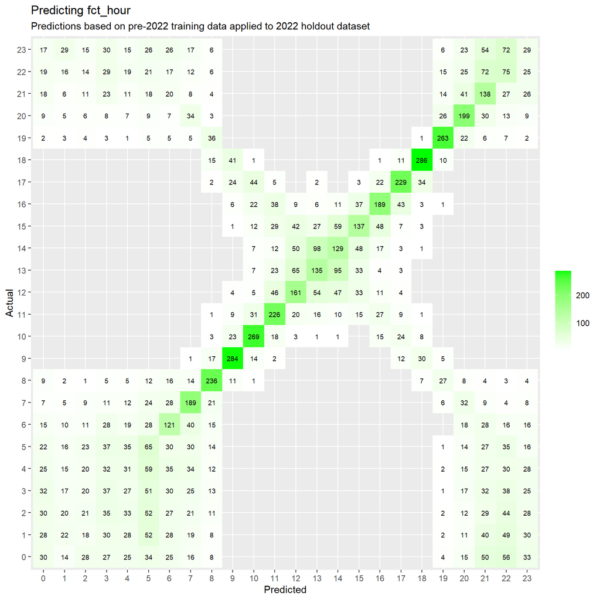

```r
dfTrain <- filter(nycTempTrain, lubridate::year(date)<2022)
dfTest <- filter(bind_rows(nycTempTest, nycTempTrain), lubridate::year(date)==2022)
keyLabel <- "predictions based on pre-2022 training data applied to 2022 holdout dataset"

runFullRF(dfTrain=dfTrain,
          yVar="fct_hour",
          xVars=varsTrain,
          dfTest=dfTest,
          useLabel=keyLabel,
          useSub=stringr::str_to_sentence(keyLabel)
          )
```

Function reportAccuracy() is updated for continuous variables:

```r
# Backup of old function
oldReportAccuracy <- reportAccuracy

# Update for continuous variables
reportAccuracy <- function(df,
                           trueCol,
                           predCol="pred",
                           reportAcc=TRUE,
                           rndReport=2,
                           useLabel="requested data",
                           returnAcc=!isTRUE(reportAcc),
                           reportR2=FALSE
                           ) {

    # FUNCTION ARGUMENTS:
    # df: data frame containing actual and predictions
    # trueCol: column containing true value
    # predCol: column containing predicted value
    # reportAcc: boolean, should accuracy be reported (printed to output)?
    # rndReport: number of significant digits for reporting (will be converted to percentage first)
    # useLabel: label for data to be used in reporting
    # returnAcc: boolean, should the accuracy be returned
    #            return value is not converted to percentage, not rounded
    # reportR2: boolean, should accuracy be calculated as R-squared?
    #           (default FALSE measures as categorical)

    # Continuous or categorical reporting
    if(isTRUE(reportR2)) {
        tc <- df %>% pull(get(trueCol))
        pc <- df %>% pull(get(predCol))
        mseNull <- mean((tc-mean(tc))**2)
        msePred <- mean((tc-pc)**2)
        r2 <- 1 - msePred/mseNull
        if(isTRUE(reportAcc))
            cat("\nR-squared of ",
                useLabel,
                " is: ",
                round(100*r2, rndReport),
                "% (RMSE ",
                round(sqrt(msePred), 2),
                " vs. ",
                round(sqrt(mseNull), 2),
                " null)\n",
                sep=""
                )
        acc <- c("mseNull"=mseNull, "msePred"=msePred, "r2"=r2)
    } else {
        acc <- mean(df[trueCol]==df[predCol])
        if(isTRUE(reportAcc))
            cat("\nAccuracy of ", useLabel, " is: ", round(100*acc, rndReport), "%\n", sep="")
    }

    # Return accuracy statistic if requested
    if(isTRUE(returnAcc)) return(acc)

}

# Test for categorical
set.seed(23121100)
dfTestCat <- tibble::tibble(trueVal=factor(sample(month.abb, 1000, replace=TRUE), levels=month.abb),
                            predNull=factor(sample(month.abb, 1000, replace=TRUE), levels=month.abb),
                            predVal=factor(month.abb[as.integer(ifelse(runif(1000)<=0.9, trueVal, predNull))],
                                           levels=month.abb
                                           )
                            )
dfTestCat
```

```
## # A tibble: 1,000 × 3
##    trueVal predNull predVal
##    <fct>   <fct>    <fct>
##  1 Oct     May      Oct
##  2 Sep     Nov      Sep
##  3 Dec     Feb      Dec
##  4 Oct     Nov      Oct
##  5 Nov     Feb      Nov
##  6 Nov     Nov      Nov
##  7 Aug     Jan      Aug
##  8 Feb     Dec      Feb
##  9 Jun     Jun      Jun
## 10 Oct     Sep      Oct
## # … with 990 more rows
```

```r
reportAccuracy(dfTestCat, trueCol="trueVal", predCol="predNull", useLabel="random 12-category null")
```

```
##
## Accuracy of random 12-category null is: 8.6%
```

```r
oldReportAccuracy(dfTestCat, trueCol="trueVal", predCol="predNull", useLabel="random 12-category null")
```

```
##
## Accuracy of random 12-category null is: 8.6%
```

```r
reportAccuracy(dfTestCat, trueCol="trueVal", predCol="predVal", useLabel="random 12-category (90% true)")
```

```
##
## Accuracy of random 12-category (90% true) is: 91.2%
```

```r
oldReportAccuracy(dfTestCat, trueCol="trueVal", predCol="predVal", useLabel="random 12-category (90% true)")
```

```
##
## Accuracy of random 12-category (90% true) is: 91.2%
```

```r
# Test for continuous
set.seed(23121100)
dfTestCont <- tibble::tibble(trueVal=rnorm(100000),
                             predNull=mean(trueVal),
                             predVal=ifelse(runif(100000)<=0.9, trueVal, predNull)
                             )
dfTestCont
```

```
## # A tibble: 100,000 × 3
##    trueVal predNull predVal
##      <dbl>    <dbl>   <dbl>
##  1   0.551  0.00113   0.551
##  2   0.872  0.00113   0.872
##  3   1.40   0.00113   1.40
##  4   0.116  0.00113   0.116
##  5   0.726  0.00113   0.726
##  6  -0.969  0.00113  -0.969
##  7  -2.10   0.00113  -2.10
##  8   0.540  0.00113   0.540
##  9  -0.115  0.00113  -0.115
## 10   1.32   0.00113   1.32
## # … with 99,990 more rows
```

```r
reportAccuracy(dfTestCont,
               trueCol="trueVal",
               predCol="predNull",
               useLabel="continuous rnorm null",
               reportR2=TRUE
               )
```

```
##
## R-squared of continuous rnorm null is: 0% (RMSE 1 vs. 1 null)
```

```r
reportAccuracy(dfTestCont,
               trueCol="trueVal",
               predCol="predVal",
               useLabel="continuous rnorm (90% true)",
               reportR2=TRUE
               )
```

```
##
## R-squared of continuous rnorm (90% true) is: 89.73% (RMSE 0.32 vs. 1 null)
```

Function plotConfusion() is updated for continuous variables:

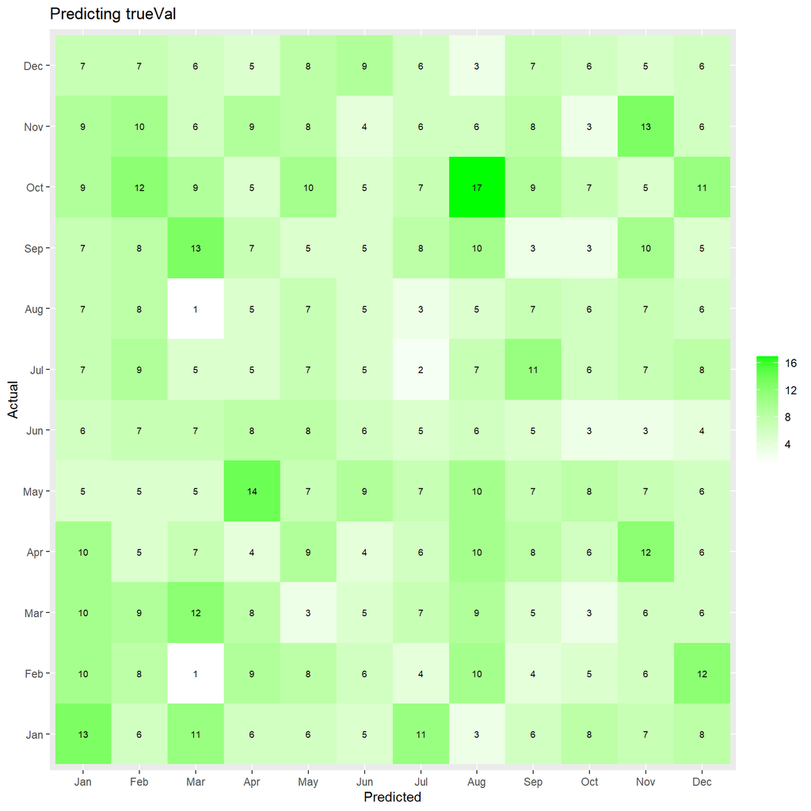

```r
# Backup of old function
oldPlotConfusion <- plotConfusion

# Update for continuous variables
plotConfusion <- function(df,
                          trueCol,
                          predCol="pred",
                          useTitle=NULL,
                          useSub=NULL,
                          plotCont=FALSE
                          ) {

    # FUNCTION ARGUMENTS:
    # df: data frame containing actual and predictions
    # trueCol: column containing true value
    # predCol: column containing predicted value
    # useTitle: title to be used for chart (NULL means create from trueCol)
    # useSub: subtitle to be used for chart (NULL means none)
    # plotCont: boolean, should plotting assume continuous variables?
    #           (default FALSE assumes confusion plot for categorical variables)

    # Create title if not supplied
    if(is.null(useTitle)) useTitle <- paste0("Predicting ", trueCol)

    # Create base plot (applicable to categorical or continuous variables)
    p1 <- df %>%
        group_by(across(all_of(c(trueCol, predCol)))) %>%
        summarize(n=n(), .groups="drop") %>%
        ggplot(aes(x=get(predCol), y=get(trueCol))) +
        labs(x="Predicted", y="Actual", title=useTitle, subtitle=useSub)

    # Update plot as appropriate
    if(isTRUE(plotCont)) {
        p1 <- p1 +
            geom_point(aes(size=n), alpha=0.5) +
            scale_size_continuous("# Obs") +
            coord_flip() +
            geom_smooth(aes(weight=n), method="lm")
    } else {
        p1 <- p1 +
            geom_tile(aes(fill=n)) +
            geom_text(aes(label=n), size=2.5) +
            scale_fill_continuous("", low="white", high="green")
    }

    # Output plot
    print(p1)

}

# Test for categorical (use same data as above)
plotConfusion(dfTestCat, trueCol="trueVal", predCol="predNull")
```

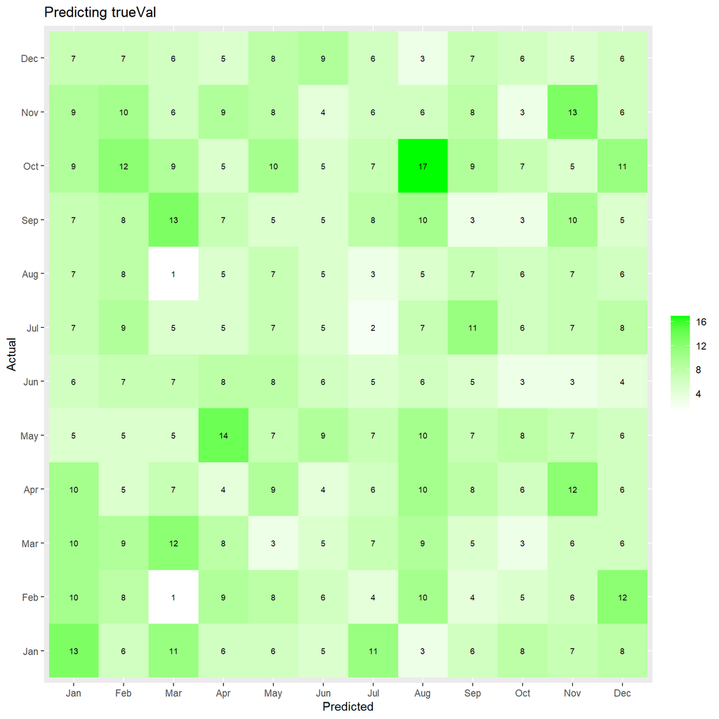

```r
oldPlotConfusion(dfTestCat, trueCol="trueVal", predCol="predNull")
```

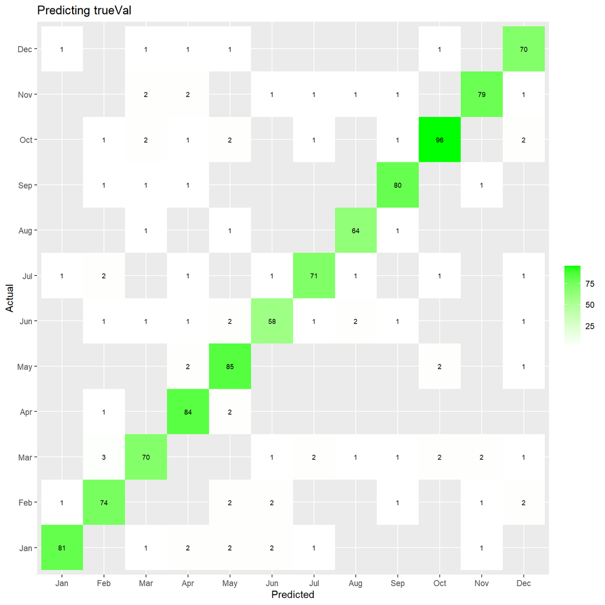

```r
plotConfusion(dfTestCat, trueCol="trueVal", predCol="predVal")
```

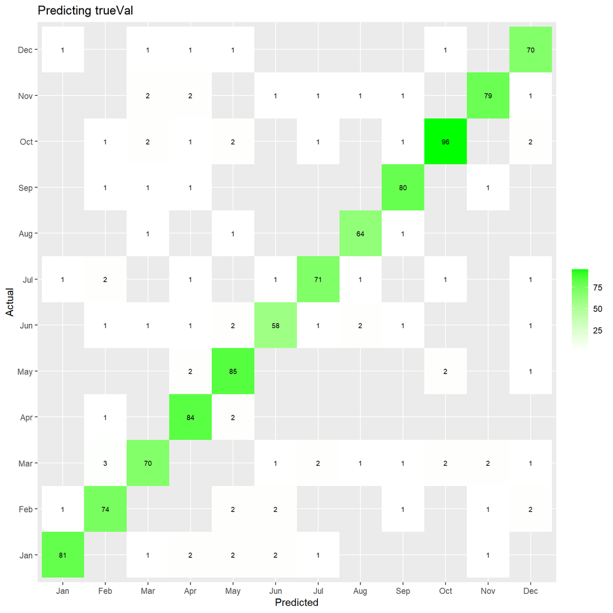

```r
oldPlotConfusion(dfTestCat, trueCol="trueVal", predCol="predVal")
```

```r
# Test for continuous (use same data as above, all data rounded to nearest 0.05)
dfTestCont05 <- dfTestCont %>% mutate(across(where(is.numeric), .fns=function(x) round(x*20)/20))
dfTestCont05
```

```
## # A tibble: 100,000 × 3
##    trueVal predNull predVal
##      <dbl>    <dbl>   <dbl>
##  1    0.55        0    0.55
##  2    0.85        0    0.85
##  3    1.4         0    1.4
##  4    0.1         0    0.1
##  5    0.75        0    0.75
##  6   -0.95        0   -0.95
##  7   -2.1         0   -2.1
##  8    0.55        0    0.55
##  9   -0.1         0   -0.1
## 10    1.3         0    1.3
## # … with 99,990 more rows
```

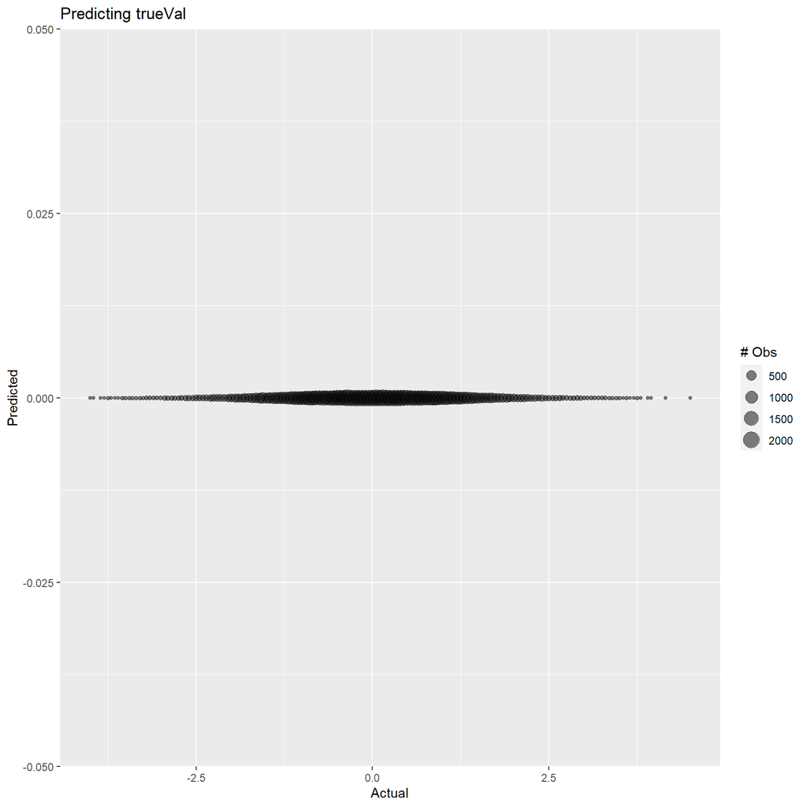

```r
plotConfusion(dfTestCont05, trueCol="trueVal", predCol="predNull", plotCont=TRUE)
```

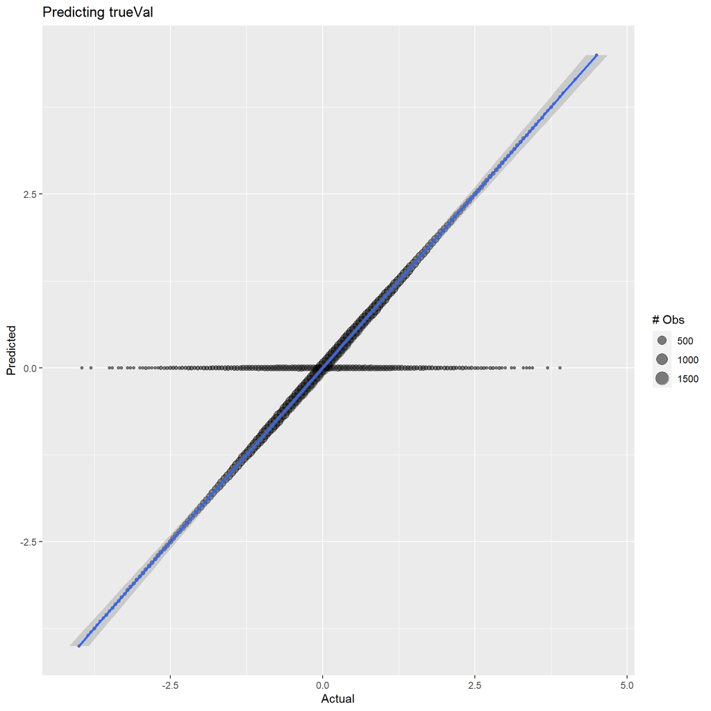

```r
plotConfusion(dfTestCont05, trueCol="trueVal", predCol="predVal", plotCont=TRUE)
```

The main function is updated to run all steps for continuous or categorical:

```r
oldRunFullRF <- runFullRF

runFullRF <- function(dfTrain,
                      yVar,
                      xVars,
                      dfTest=dfTrain,
                      useLabel="test data",
                      useSub=NULL,
                      isContVar=FALSE,
                      returnData=FALSE,
                      ...
                      ) {

    # FUNCTION ARGUMENTS:
    # dfTrain: training data
    # yVar: dependent variable
    # xVars: column(s) containing independent variables
    # dfTest: test dataset for applying predictions
    # useLabel: label to be used for reporting accuracy
    # useSub: subtitle to be used for confusion chart (NULL means none)
    # isContVar: boolean, is the variable continuous? (default FALSE means categorical)
    # returnData: boolean, should data be returned?
    # ...: additional parameters to pass to runSimpleRF(), which are then passed to ranger::ranger()

    # 1. Run random forest using impurity for importance
    rf <- runSimpleRF(df=dfTrain, yVar=yVar, xVars=xVars, importance="impurity", ...)

    # 2. Plot variable importance
    rfImp <- plotRFImportance(rf, returnData=TRUE)

    # 3. Predict on test dataset
    tstPred <- predictRF(rf=rf, df=dfTest)

    # 4. Report on accuracy (updated for continuous or categorical)
    rfAcc <- reportAccuracy(tstPred,
                            trueCol=yVar,
                            rndReport=3,
                            useLabel=useLabel,
                            reportR2=isTRUE(isContVar),
                            returnAcc=TRUE
                            )

    # 5. Plot confusion data (updated for continuous vs. categorical)
    plotConfusion(tstPred, trueCol=yVar, useSub=useSub, plotCont=isTRUE(isContVar))

    #6. Return data if requested
    if(isTRUE(returnData)) return(list(rf=rf, rfImp=rfImp, tstPred=tstPred, rfAcc=rfAcc))

}
```